# Ejercicio práctico desarrollo modelo de credit scoring

Daniel Fuentes

Mayo 2022

## R Markdown

EJERCICIO 1: EXTRACCIÓN Y VALIDACIÓN DE LOS DATOS

El primer paso en cualquier tipo de modelo de scoring o de rating es conocer bien los datos de los que dispones. Conocer bien el dataset sobre el que se trabaja puede determinar que un modelo sea útil y con buen poder predictivo o no.

En este caso tenemos una base de datos de préstamos obtenido en el siguiente enlace:

https://www.lendingclub.com/info/download-data.action

Se trata de una Fintech que concede préstamos a través de dinero de inversores. Cada solicitud es evaluada y catalogada en diferentes categorías de riesgo. Los inversores recibirán un mayor o menor interés en función de como de riesgosa sea la cartera de préstamos en los que invierta.

Además proveen de un excel con el significado de cada variable.

El dataset era de un tamaño considerable (600Mb) y ha sido reducido para que podáis trabajar más fácilmente y rápido a modo de ejemplo.

En la mayor parte de cursos de scoring podréis ver como se centran en lo que es el propio algoritmo: regresión logística, árboles de decisión, random forest…, lanzar este tipo de modelos es fácil pero no lo más importante, sobre todo desde el punto de vista práctico, donde un analista de crédito o usuario del modelo debe comprender el modelo y estar conforme o cómodo con él. Vamos a preparar y cargar todas las librerías necesarias para poder ejecutar todo el código que os mostramos a continuación:

```r
# if(!is.element("plyr", installed.packages()[, 1])) install.packages("plyr")
# if(!is.element("lattice", installed.packages()[, 1])) install.packages("lattice")
# if(!is.element("plotly", installed.packages()[, 1])) install.packages("plotly")
# if(!is.element("ggplot2", installed.packages()[, 1])) install.packages("ggplot2")
# if(!is.element("Hmisc", installed.packages()[, 1])) install.packages("Hmisc")
# if(!is.element("sqldf", installed.packages()[, 1])) install.packages("sqldf")
# if(!is.element("zoo", installed.packages()[, 1])) install.packages("zoo")
# if(!is.element("caTools", installed.packages()[, 1])) install.packages("caTools")
# if(!is.element("RcmdrMisc", installed.packages()[, 1])) install.packages("RcmdrMisc")
# if(!is.element("smbinning", installed.packages()[, 1])) install.packages("smbinning")
# if(!is.element("DBI", installed.packages()[, 1])) install.packages("DBI")
# if(!is.element("vcd", installed.packages()[, 1])) install.packages("vcd")
# if(!is.element("ROCR", installed.packages()[, 1])) install.packages("ROCR")
# if(!is.element("corrplot", installed.packages()[, 1])) install.packages("corrplot")
# if(!is.element("partykit", installed.packages()[, 1])) install.packages("partykit")
# if(!is.element("rpart", installed.packages()[, 1])) install.packages("rpart")
# if(!is.element("stringr", installed.packages()[, 1])) install.packages("stringr")
# if(!is.element("lubridate", installed.packages()[, 1])) install.packages("lubridate")
# if(!is.element("plyr", installed.packages()[, 1])) install.packages("plyr")
# if(!is.element("dplyr", installed.packages()[, 1])) install.packages("dplyr")
# if(!is.element("leaps", installed.packages()[, 1])) install.packages("leaps")
# if(!is.element("randomForest", installed.packages()[, 1])) install.packages("randomForest")
# if(!is.element("fBasics", installed.packages()[, 1])) install.packages("fBasics")
# if(!is.element("tabplot", installed.packages()[, 1])) install.packages("tabplot")
# if(!is.element("dataMaid", installed.packages()[, 1])) install.packages("dataMaid")
# if(!is.element("smbinning", installed.packages()[, 1])) install.packages("smbinning")
# if(!is.element("RDCOMClient", installed.packages()[, 1])) install.packages('RDCOMClient', repos = 'http://www.stats.ox.ac.uk/pub/RWin/')
# if(!is.element("ggcorrplot", installed.packages()[, 1])) install.packages("ggcorrplot")
# if(!is.element("Amelia", installed.packages()[, 1])) install.packages("Amelia")
# if(!is.element("ggplot", installed.packages()[, 1])) install.packages("ggplot")
# if(!is.element("randomForest", installed.packages()[, 1])) install.packages("randomForest")
# if(!is.element("ada", installed.packages()[, 1])) install.packages("ada")
# if(!is.element("patchwork", installed.packages()[, 1])) install.packages("patchwork")
# if(!is.element("DataExplorer", installed.packages()[, 1])) install.packages("DataExplorer ")



library(smbinning)
library(corrplot)
library(Hmisc)
library(sqldf)
library(zoo)
library(caTools)
library(RcmdrMisc)
library(ROCR)
library(vcd)
library(ggplot2)
library(plotly)
library(lattice)
library(plyr)
library(partykit)
library(rpart)
library(stringr)
library(lubridate)
library(plyr)
library(dplyr)
library(leaps)
library(randomForest)
library(fBasics)
library(dataMaid)
library(DescTools)
library(ggcorrplot)
library(Amelia)
library(DataExplorer)
library(ggplot2)
library(lubridate)
```

Vamos a cargar la base de datos que hemos preparado y analizar todas las variables que tenemos disponibles:

```r
# load("Database_LoansAFI.RData")

library(readxl)
Loans <- read_excel("C:/Users/Javier/Documents/masterAFI/20. Masterclass/06. Credit Scoring/Loans.xlsx")
colnames(Loans)
```

```
##  [1] "id"                     "loan_amnt"              "term"
##  [4] "int_rate"               "installment"            "grade"
##  [7] "emp_title"              "emp_length"             "home_ownership"
## [10] "annual_inc"             "verification_status"    "issue_d"
## [13] "loan_status"            "desc"                   "purpose"
## [16] "addr_state"             "dti"                    "delinq_2yrs"
## [19] "earliest_cr_line"       "Fico_score"             "inq_last_6mths"
## [22] "mths_since_last_delinq" "mths_since_last_record" "open_acc"
## [25] "revol_bal"              "revol_util"
```

```r
dim(Loans)
```

```
## [1] 39786    26
```

Analicemos la estructura de las variables del modelo y vamos estudiando poco a poco cada una de ellas:

```
## tibble [39,786 x 26] (S3: tbl_df/tbl/data.frame)
##  $ id                    : num [1:39786] 1077501 1077430 1077175 1076863 1075358 ...
##  $ loan_amnt             : num [1:39786] 5000 2500 2400 10000 3000 ...
##  $ term                  : chr [1:39786] "36 months" "60 months" "36 months" "36 months" ...
##  $ int_rate              : chr [1:39786] "10.65%" "15.27%" "15.96%" "13.49%" ...
##  $ installment           : num [1:39786] 162.9 59.8 84.3 339.3 67.8 ...
##  $ grade                 : chr [1:39786] "B" "C" "C" "C" ...
##  $ emp_title             : chr [1:39786] NA "Ryder" NA "AIR RESOURCES BOARD" ...
##  $ emp_length            : chr [1:39786] "10+ years" "< 1 year" "10+ years" "10+ years" ...
##  $ home_ownership        : chr [1:39786] "RENT" "RENT" "RENT" "RENT" ...
##  $ annual_inc            : num [1:39786] 24000 30000 12252 49200 80000 ...
##  $ verification_status   : chr [1:39786] "Verified" "Source Verified" "Not Verified" "Source Verified" ...
##  $ issue_d               : chr [1:39786] "11-Dec" "11-Dec" "11-Dec" "11-Dec" ...
##  $ loan_status           : chr [1:39786] "Fully Paid" "Default" "Fully Paid" "Fully Paid" ...
##  $ desc                  : chr [1:39786] "Borrower added on 12/22/11 > I need to upgrade my business technologies.<br>" "Borrower added on 12/22/11 > I plan to use this money to finance the motorcycle i am looking at. I plan to have"| __truncated__ NA "Borrower added on 12/21/11 > to pay for prop…
##  $ purpose               : chr [1:39786] "credit_card" "car" "small_business" "other" ...
##  $ addr_state            : chr [1:39786] "AZ" "GA" "IL" "CA" ...
##  $ dti                   : num [1:39786] 27.65 1 8.72 20 17.94 ...
##  $ delinq_2yrs           : num [1:39786] 0 0 0 0 0 0 0 0 0 0 ...
##  $ earliest_cr_line      : chr [1:39786] "Jan-85" "Apr-99" "1-Nov" "Feb-96" ...
##  $ Fico_score            : num [1:39786] 735 740 735 690 695 730 690 660 675 725 ...
##  $ inq_last_6mths        : num [1:39786] 1 5 2 1 0 3 1 2 2 0 ...
##  $ mths_since_last_delinq: num [1:39786] NA NA NA 35 38 NA NA NA NA NA ...
##  $ mths_since_last_record: num [1:39786] NA NA NA NA NA NA NA NA NA NA ...
##  $ open_acc              : num [1:39786] 3 3 2 10 15 9 7 4 11 2 ...
##  $ revol_bal             : num [1:39786] 13648 1687 2956 5598 27783 ...
##  $ revol_util            : chr [1:39786] "83.70%" "9.40%" "98.50%" "21%" ...
```

Como podéis obsevar hay variables numéricas y categóricas y precisamente su tratamiento deberá ser realizado de manera diferente. Ya se dejan ver algunas variables que tienen algunos valores missing y podemos ver cuál es nuestra variable target o la que queremos predecir en nuestros préstamos: loan_status.

Veamos los 5 primeros registros del dataset para seguir haciéndonos una idea de la información con la que contamos:

```r
head(Loans,n=5)
```

```
## # A tibble: 5 x 26
##        id loan_amnt term      int_rate installment grade emp_title    emp_length
##     <dbl>     <dbl> <chr>     <chr>          <dbl> <chr> <chr>        <chr>
## 1 1077501      5000 36 months 10.65%         163.  B     <NA>         10+ years
## 2 1077430      2500 60 months 15.27%          59.8 C     Ryder        < 1 year
## 3 1077175      2400 36 months 15.96%          84.3 C     <NA>         10+ years
## 4 1076863     10000 36 months 13.49%         339.  C     AIR RESOURC~ 10+ years
## 5 1075358      3000 60 months 12.69%          67.8 B     University ~ 1 year
## # ... with 18 more variables: home_ownership <chr>, annual_inc <dbl>,
## #   verification_status <chr>, issue_d <chr>, loan_status <chr>, desc <chr>,
## #   purpose <chr>, addr_state <chr>, dti <dbl>, delinq_2yrs <dbl>,
## #   earliest_cr_line <chr>, Fico_score <dbl>, inq_last_6mths <dbl>,
## #   mths_since_last_delinq <dbl>, mths_since_last_record <dbl>, open_acc <dbl>,
## #   revol_bal <dbl>, revol_util <chr>
```

Lo mismo podría hacerse para ver los últimos registros del dataset

```r
tail(Loans,n=7)
```

```
## # A tibble: 7 x 26
##      id loan_amnt term      int_rate installment grade emp_title      emp_length
##   <dbl>     <dbl> <chr>     <chr>          <dbl> <chr> <chr>          <chr>
## 1 92507      5000 36 months 7.43%          155.  A     Rush Univ Med~ 1 year
## 2 92402      5000 36 months 8.70%          158.  B     A. F. Wolfers~ 5 years
## 3 92187      2500 36 months 8.07%           78.4 A     FiSite Resear~ 4 years
## 4 90665      8500 36 months 10.28%         275.  C     Squarewave So~ 3 years
## 5 90395      5000 36 months 8.07%          157.  A     <NA>           < 1 year
## 6 90376      5000 36 months 7.43%          155.  A     <NA>           < 1 year
## 7 87023      7500 36 months 13.75%         255.  E     Evergreen Cen~ < 1 year
## # ... with 18 more variables: home_ownership <chr>, annual_inc <dbl>,
## #   verification_status <chr>, issue_d <chr>, loan_status <chr>, desc <chr>,
## #   purpose <chr>, addr_state <chr>, dti <dbl>, delinq_2yrs <dbl>,
## #   earliest_cr_line <chr>, Fico_score <dbl>, inq_last_6mths <dbl>,
## #   mths_since_last_delinq <dbl>, mths_since_last_record <dbl>, open_acc <dbl>,
## #   revol_bal <dbl>, revol_util <chr>
```

Se tendrán que ir analizando variable a variable como se comportan, como se encuentran en el dataset y modifarlas si procede:

```r
#Clases de cada variable
Class<-as.data.frame(sapply(Loans, class))
colnames(Class)<-"variable_class"
Class$variable_name<-row.names(Class)
row.names(Class)<-NULL

Class
```

```
##    variable_class          variable_name
## 1         numeric                     id
## 2         numeric              loan_amnt
## 3       character                   term
## 4       character               int_rate
## 5         numeric            installment
## 6       character                  grade
## 7       character              emp_title
## 8       character             emp_length
## 9       character         home_ownership
## 10        numeric             annual_inc
## 11      character    verification_status
## 12      character                issue_d
## 13      character            loan_status
## 14      character                   desc
## 15      character                purpose
## 16      character             addr_state
## 17        numeric                    dti
## 18        numeric            delinq_2yrs
## 19      character       earliest_cr_line
## 20        numeric             Fico_score
## 21        numeric         inq_last_6mths
## 22        numeric mths_since_last_delinq
## 23        numeric mths_since_last_record
## 24        numeric               open_acc
## 25        numeric              revol_bal
## 26      character             revol_util
```

```r
Class[Class$variable_class=="integer",]
```

```
## [1] variable_class variable_name
## <0 rows> (or 0-length row.names)
```

```r
for (i in 1:ncol(Loans)){

  if (class(Loans[,i])=="integer"){


    Loans[,i]<-as.numeric(Loans[,i])

  }

}
```

[output not shown]

[output cut: 22 more lines]

[output not shown]

Vamos a ir analizando ahora variable a variable las variables categóricas y haciendo trasnformaciones si es necesario:

```r
Class[Class$variable_class=="character",]
```

```
##    variable_class       variable_name
## 3       character                term
## 4       character            int_rate
## 6       character               grade
## 7       character           emp_title
## 8       character          emp_length
## 9       character      home_ownership
## 11      character verification_status
## 12      character             issue_d
## 13      character         loan_status
## 14      character                desc
## 15      character             purpose
## 16      character          addr_state
## 19      character    earliest_cr_line
## 26      character          revol_util
```

Empecemos con la variable plazo del préstamo:

```r
table(Loans$term)
```

```
##
## 36 months 60 months
##     29096     10690
```

Esta variable podría convertirse a numérica pero dado que solamente toma dos valores la vamos a mantener así. Veamos la siguiente variable: int_rate (tipo de interés del préstamo):

```r
head(Loans$int_rate)
```

```
## [1] "10.65%" "15.27%" "15.96%" "13.49%" "12.69%" "7.90%"
```

La variable es numérica pero aparece como categórica, vamos a transformarla:

```r
Loans$int_rate<-as.numeric(gsub("%","",Loans$int_rate))/100

summary(Loans$int_rate)
```

```
##    Min. 1st Qu.  Median    Mean 3rd Qu.    Max.
##  0.0542  0.0925  0.1186  0.1203  0.1459  0.2459
```

Variable “grade” (Categoria de riesgo que asigna LendingClub a cada préstamo):

```r
table(Loans$grade)
```

```
##
##     A     B     C     D     E     F     G
## 10085 12035  8111  5325  2858  1054   318
```

La categoría A corresponde a préstamos de solicitantes con mejor perfil de pago o más solventes, siendo la G la categoría de préstamos más riesgosa:

Más variables que están disponibles: Descripción del puesto que ocupa el solicitante en la empresa:

```r
head(table(Loans$emp_title))
```

```
##
## $260M '06 vintage technology venture capital firm
##                                                 1
##             (Collaborative) Abbott Nutrition Intl
##                                                 1
##                          (self) Castleforte Group
##                                                 1
##                                          :coderow
##                                                 1
##                                    1-800 Contacts
##                                                 1
##                                 1 Cochran Hyundai
##                                                 1
```

```r
print("La variable tiene ")
```

```
## [1] "La variable tiene "
```

```r
(length(table(Loans$emp_title)))
```

```
## [1] 28660
```

```r
print("valores diferentes.")
```

```
## [1] "valores diferentes."
```

Variable “emp_length” o antigüedad en el empleo:

```r
table(Loans$emp_length)
```

```
##
##  < 1 year    1 year 10+ years   2 years   3 years   4 years   5 years   6 years
##      4590      3247      8899      4394      4098      3444      3286      2231
##   7 years   8 years   9 years       n/a
##      1775      1485      1259      1078
```

Vamos a transformar la variable en numérica. Si el valor que toma es “< 1 year” pondremos un 0 y si es mayor que 10 se convertira en 10 años.

```r
Loans$emp_length<-gsub("years","",Loans$emp_length)
Loans$emp_length<-gsub("year","",Loans$emp_length)
Loans$emp_length<-gsub("< 1","0",Loans$emp_length)
Loans$emp_length<-gsub("[+]","",Loans$emp_length)
Loans$emp_length<-as.numeric(Loans$emp_length)
summary(Loans$emp_length)
```

```
##    Min. 1st Qu.  Median    Mean 3rd Qu.    Max.    NA's
##   0.000   2.000   4.000   4.974   9.000  10.000    1078
```

Más variables:

“home_ownership”: Situación de la vivienda habitual

```r
table(Loans$home_ownership)
```

```
##
## MORTGAGE    OTHER      OWN     RENT
##    17703      101     3064    18918
```

“verification_status”: Si los ingresos declarados por el solicitante han sido verificados o no

```r
table(Loans$verification_status)
```

```
##
##    Not Verified Source Verified        Verified
##           16926           10016           12844
```

“purpose”: Destino del préstamo

```r
table(Loans$purpose)
```

```
##
##                car        credit_card debt_consolidation        educational
##               1551               5137              18676                325
##   home_improvement              house     major_purchase            medical
##               2985                382               2188                695
##             moving              other   renewable_energy     small_business
##                583               4001                103               1831
##           vacation            wedding
##                381                948
```

“addr_state”: Estado de residencia del solicitante, los datos son de solicitudes en Estados Unidos.

```r
table(Loans$addr_state)
```

```
##
##   AK   AL   AR   AZ   CA   CO   CT   DC   DE   FL   GA   HI   IA   ID   IL   IN
##   81  452  246  882 7105  792  754  214  114 2872 1399  174    5    6 1525    9
##   KS   KY   LA   MA   MD   ME   MI   MN   MO   MS   MT   NC   NE   NH   NJ   NM
##  272  327  436 1344 1055    3  722  616  686   19   85  789    5  172 1855  190
##   NV   NY   OH   OK   OR   PA   RI   SC   SD   TN   TX   UT   VA   VT   WA   WI
##  498 3817 1226  300  451 1519  199  472   64   17 2734  259 1408   54  842  460
##   WV   WY
##  177   83
```

Con la variable “revol_util” o porcentaje de las líneas de crédito que tiene utilizadas, ocurre lo mismo que con la variable tipo de interés. Convertimos de igual forma la variable en numérica:

```r
head(Loans$revol_util)
```

```
## [1] "83.70%" "9.40%"  "98.50%" "21%"    "53.90%" "28.30%"
```

```r
Loans$revol_util<-as.numeric(gsub("%","",Loans$revol_util))/100

summary(Loans$revol_util)
```

```
##    Min. 1st Qu.  Median    Mean 3rd Qu.    Max.    NA's
##  0.0000  0.2540  0.4930  0.4886  0.7240  0.9990      50
```

La variable “issue_d” es la fecha en la que el préstamo fue concedido, como está en formato carácter, vamos a convertirla en formato fecha:

```r
head(Loans$issue_d)
```

```
## [1] "11-Dec" "11-Dec" "11-Dec" "11-Dec" "11-Dec" "11-Dec"
```

```r
tail(Loans$issue_d)
```

```
## [1] "7-Jul" "7-Jul" "7-Jul" "7-Jul" "7-Jul" "7-Jun"
```

```r
unique(Loans$issue_d)
```

```
##  [1] "11-Dec" "11-Nov" "11-Oct" "11-Sep" "11-Aug" "11-Jul" "11-Jun" "11-May"
##  [9] "11-Apr" "11-Mar" "11-Feb" "11-Jan" "10-Dec" "10-Nov" "10-Oct" "10-Sep"
## [17] "10-Aug" "10-Jul" "10-Jun" "10-May" "10-Apr" "10-Mar" "10-Feb" "10-Jan"
## [25] "9-Dec"  "9-Nov"  "9-Oct"  "9-Sep"  "9-Aug"  "9-Jul"  "9-Jun"  "9-May"
## [33] "9-Apr"  "9-Mar"  "9-Feb"  "9-Jan"  "8-Dec"  "8-Nov"  "8-Oct"  "8-Sep"
## [41] "8-Aug"  "8-Jul"  "8-Jun"  "8-May"  "8-Apr"  "8-Mar"  "8-Feb"  "8-Jan"
## [49] "7-Dec"  "7-Nov"  "7-Oct"  "7-Sep"  "7-Aug"  "7-Jul"  "7-Jun"
```

```r
Loans$issue_d<-ymd(paste(Loans$issue_d,"-01",sep=""))

unique(Loans$issue_d)
```

```
##  [1] "2011-12-01" "2011-11-01" "2011-10-01" "2011-09-01" "2011-08-01"
##  [6] "2011-07-01" "2011-06-01" "2011-05-01" "2011-04-01" "2011-03-01"
## [11] "2011-02-01" "2011-01-01" "2010-12-01" "2010-11-01" "2010-10-01"
## [16] "2010-09-01" "2010-08-01" "2010-07-01" "2010-06-01" "2010-05-01"
## [21] "2010-04-01" "2010-03-01" "2010-02-01" "2010-01-01" "2009-12-01"
## [26] "2009-11-01" "2009-10-01" "2009-09-01" "2009-08-01" "2009-07-01"
## [31] "2009-06-01" "2009-05-01" "2009-04-01" "2009-03-01" "2009-02-01"
## [36] "2009-01-01" "2008-12-01" "2008-11-01" "2008-10-01" "2008-09-01"
## [41] "2008-08-01" "2008-07-01" "2008-06-01" "2008-05-01" "2008-04-01"
## [46] "2008-03-01" "2008-02-01" "2008-01-01" "2007-12-01" "2007-11-01"
## [51] "2007-10-01" "2007-09-01" "2007-08-01" "2007-07-01" "2007-06-01"
```

```r
class(Loans$issue_d)
```

```
## [1] "Date"
```

También la variable “earliest_cr_line” o fecha en la que el solicitante abrió su primera cuenta se encuentra en formato texto. La transformamos de igual forma a formato fecha:

```r
head(Loans$earliest_cr_line)
```

```
## [1] "Jan-85" "Apr-99" "1-Nov"  "Feb-96" "Jan-96" "4-Nov"
```

```r
Loans$earliest_cr_line<-dmy(paste("01-",Loans$earliest_cr_line,sep=""))
head(Loans$earliest_cr_line)
```

```
## [1] "1985-01-01" "1999-04-01" NA           "1996-02-01" "1996-01-01"
## [6] NA
```

```r
save.image("Backup1.RData")
```

Con esta variable, vamos a calcular la antigüedad del cliente en la entidad, para ello restaremos las fechas de concesión de solicitud del préstamo con la fecha que acabamos de obtener. La variable antigüedad como cliente estará expresada en años:

```r
Loans$ant_cliente<-as.numeric(round((Loans$issue_d-Loans$earliest_cr_line)/365,0))

summary(Loans$ant_cliente)
```

```
##    Min. 1st Qu.  Median    Mean 3rd Qu.    Max.    NA's
##  -60.00   12.00   15.00   16.31   19.00   43.00   11612
```

```r
table(Loans$ant_cliente)
```

```
##
##  -60  -59  -58  -57  -56  -55  -54  -53  -52  -51  -48  -45  -44  -43  -40  -35
##    2    4   10   15   13   10    9    8    8    5    1    1    1    1    1    1
##    7    8    9   10   11   12   13   14   15   16   17   18   19   20   21   22
##   42  140  505 1445 2815 3015 2712 2395 2129 1980 1660 1292 1091  984  916  784
##   23   24   25   26   27   28   29   30   31   32   33   34   35   36   37   38
##  650  582  470  417  362  276  226  176  163  181  123  122   85   61   80   53
##   39   40   41   42   43
##   50   37   44   20    1
```

Podemos ver que hay algunos registros que aparecen con un valor negativo, parece que se debe a algún tipo de error. Vemos también que la variable parece tener muchos valores no informados. Los valores negativos serán remplazados por un valor 0:

```r
Loans$ant_cliente<-ifelse(Loans$ant_cliente<0,0,Loans$ant_cliente)

summary(Loans$ant_cliente)
```

```
##    Min. 1st Qu.  Median    Mean 3rd Qu.    Max.    NA's
##    0.00   12.00   15.00   16.49   19.00   43.00   11612
```

Vamos a crear otra variable relacionada cn esta: una marca que nos indique si el solicitante es cliente anteriormente o no:

```r
Loans$flag_cliente<-ifelse(Loans$ant_cliente>0,1,0)

Loans$flag_cliente<-ifelse(is.na(Loans$flag_cliente),0,1)

summary(Loans$flag_cliente)
```

```
##    Min. 1st Qu.  Median    Mean 3rd Qu.    Max.
##  0.0000  0.0000  1.0000  0.7081  1.0000  1.0000
```

EJERCICIO 2: DEFINICIÓN DE PERFORMANCE Y MUESTRAS

Normalmente la variable target suele ser la marca de default, o lo que es lo mismo, una variable que toma dos valores: 0 si el cliente pagó su préstamo o 1 en el caso de que fuera un cliente moroso.

Se suele mirar si un cliente presento problemas de pago en un periodo de tiempo concreto, lo más común es marcar a un cliente como default si tuvo incumplimientos en las cuotas de sus préstamos en más de 90 días (definición regulatoria) durante un periodo de un año o superior.

Vamos a ver qué valores toma nuestra variable target:

```r
table(Loans$loan_status)
```

```
##
##    Default Fully Paid
##       5671      34115
```

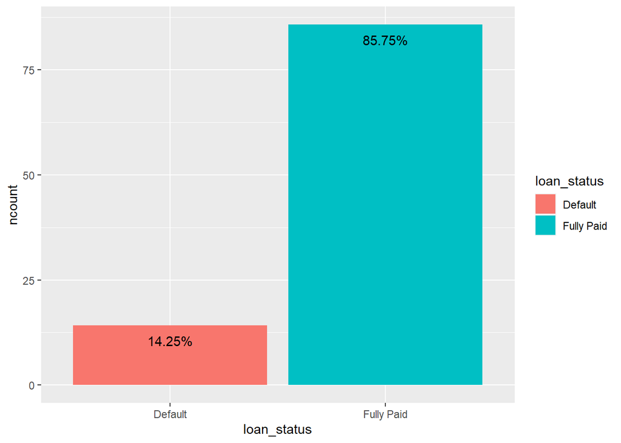

```r
tmp = Loans %>% group_by(loan_status) %>% summarise(ncount = n())
tmp$ncount = 100 * tmp$ncount/nrow(Loans)
tmp$ncount_p = str_c(round(tmp$ncount,2),"%")
ggplot(tmp,aes(x=loan_status,y=ncount,fill=loan_status)) + geom_bar(stat="identity") +
geom_text(aes(label=ncount_p),vjust = 2)
```

Como vemos, esto supone que el 14.25% de los préstamos presentaron problemas de pago. Vamos a transformar los valores Default y FullyPaid en valores numéricos. Así si un préstamo presenta problemas será marcado como un 1, un 0 en caso contrario:

```r
Loans$loan_status<-ifelse(Loans$loan_status=="Default",1,0)
```

Nos queda una última variable categórica: “desc”, que no hemos analizado. En esta variable se detalla en texto libre los comentarios que introduce el solicitante en la aplicación/web cuando solicitan el préstamo, aclarando el objeto del préstamo, más allá de la categoría genérica que queda recogida en la variable “purpose”:

```r
head(Loans$desc)
```

```
## [1] "Borrower added on 12/22/11 > I need to upgrade my business technologies.<br>"
## [2] "Borrower added on 12/22/11 > I plan to use this money to finance the motorcycle i am looking at. I plan to have it paid off as soon as possible/when i sell my old bike. I only need this money because the deal im looking at is to good to pass up.<br><br>  Borrower added on 12/22/11 > I plan t…
## [3] NA
## [4] "Borrower added on 12/21/11 > to pay for property tax (borrow from friend, need to pay back) & central A/C need to be replace. I'm very sorry to let my loan expired last time.<br>"
## [5] "Borrower added on 12/21/11 > I plan on combining three large interest bills together and freeing up some extra each month to pay toward other bills.  I've always been a good payor but have found myself needing to make adjustments to my budget due to a medical scare. My job is very stable, I …
## [6] NA
```

Esta variable no será utilizada.

Respecto a las variables numéricas, podemos hacer un análisis similar observando que valores toman las variables:

```r
#Clases de cada variable
Class<-as.data.frame(sapply(Loans, class))
colnames(Class)<-"variable_class"
Class$variable_name<-row.names(Class)
row.names(Class)<-NULL


numeric_vars<-Class[Class$variable_class=="numeric","variable_name"]
numeric_vars
```

```
##  [1] "id"                     "loan_amnt"              "int_rate"
##  [4] "installment"            "emp_length"             "annual_inc"
##  [7] "loan_status"            "dti"                    "delinq_2yrs"
## [10] "Fico_score"             "inq_last_6mths"         "mths_since_last_delinq"
## [13] "mths_since_last_record" "open_acc"               "revol_bal"
## [16] "revol_util"             "ant_cliente"            "flag_cliente"
```

```r
categorical_vars<-Class[Class$variable_class=="character","variable_name"]
```

Con el paquete fBasics podemos obtener rápidamente descriptivos básicos de las variables numéricas:

```r
library(fBasics)

descriptives_num<-as.data.frame(t(basicStats(Loans[,numeric_vars])))

descriptives_num
```

```
##                         nobs   NAs    Minimum      Maximum 1. Quartile
## id                     39786     0 54734.0000 1077501.0000 516351.7500
## loan_amnt              39786     0   500.0000   35000.0000   5500.0000
## int_rate               39786     0     0.0542       0.2459      0.0925
## installment            39786     0    15.6900    1305.1900    167.0800
## emp_length             39786  1078     0.0000      10.0000      2.0000
## annual_inc             39786     0  4000.0000 6000000.0000  40500.0000
## loan_status            39786     0     0.0000       1.0000      0.0000
## dti                    39786     0     0.0000      29.9900      8.1800
## delinq_2yrs            39786     0     0.0000      11.0000      0.0000
## Fico_score             39786     0   625.0000     825.0000    685.0000
## inq_last_6mths         39786     0     0.0000       8.0000      0.0000
## mths_since_last_delinq 39786 25727     0.0000     120.0000     18.0000
## mths_since_last_record 39786 36995     0.0000     129.0000     22.5000
## open_acc               39786     0     2.0000      44.0000      6.0000
## revol_bal              39786     0     0.0000  149588.0000   3704.2500
## revol_util             39786    50     0.0000       0.9990      0.2540
## ant_cliente            39786 11612     0.0000      43.0000     12.0000
## flag_cliente           39786     0     0.0000       1.0000      0.0000
##                        3. Quartile         Mean      Median          Sum
## id                     837871.0000 6.833939e+05 666229.5000 2.718951e+10
## loan_amnt               15000.0000 1.123136e+04  10000.0000 4.468509e+08
## int_rate                    0.1459 1.202790e-01      0.1186 4.785410e+03
## installment               430.7800 3.247336e+02    280.6100 1.291985e+07
## emp_length                  9.0000 4.974346e+00      4.0000 1.925470e+05
## annual_inc              82342.5000 6.897907e+04  59000.0000 2.744401e+09
## loan_status                 0.0000 1.425380e-01      0.0000 5.671000e+03
## dti                        18.6000 1.331779e+01     13.4100 5.298618e+05
## delinq_2yrs                 0.0000 1.465340e-01      0.0000 5.830000e+03
## Fico_score                740.0000 7.149980e+02    710.0000 2.844691e+07
## inq_last_6mths              1.0000 8.690490e-01      1.0000 3.457600e+04
## mths_since_last_delinq     52.0000 3.590191e+01     34.0000 5.047450e+05
## mths_since_last_record    104.0000 6.974740e+01     90.0000 1.946650e+05
## open_acc                   12.0000 9.294023e+00      9.0000 3.697720e+05
## revol_bal               17065.0000 1.339198e+04   8859.5000 5.328135e+08
## revol_util                  0.7240 4.885810e-01      0.4930 1.941426e+04
## ant_cliente                19.0000 1.648626e+01     15.0000 4.644840e+05
## flag_cliente                1.0000 7.081390e-01      1.0000 2.817400e+04
##                            SE Mean     LCL Mean     UCL Mean     Variance
## id                     1056.214156 6.813237e+05 6.854642e+05 4.438480e+10
```

[output cut: 21 more lines]

```
## installment            2.089232e+02  1.126760    1.240869
## emp_length             3.562961e+00  0.200407   -1.365811
## annual_inc             6.376263e+04 30.938998 2302.814060
## loan_status            3.496050e-01  2.044899    2.181665
## dti                    6.678300e+00 -0.027759   -0.850982
## delinq_2yrs            4.918260e-01  5.019368   39.360725
## Fico_score             3.584068e+01  0.464756   -0.558091
## inq_last_6mths         1.070069e+00  1.389730    2.558412
## mths_since_last_delinq 2.201789e+01  0.306403   -0.842904
## mths_since_last_record 4.380507e+01 -0.718537   -1.154322
## open_acc               4.399997e+00  1.003384    1.675974
## revol_bal              1.589464e+04  3.189163   14.870777
## revol_util             2.833660e-01 -0.034928   -1.105870
## ant_cliente            5.994798e+00  1.267477    1.912245
## flag_cliente           4.546250e-01 -0.915627   -1.161656
```

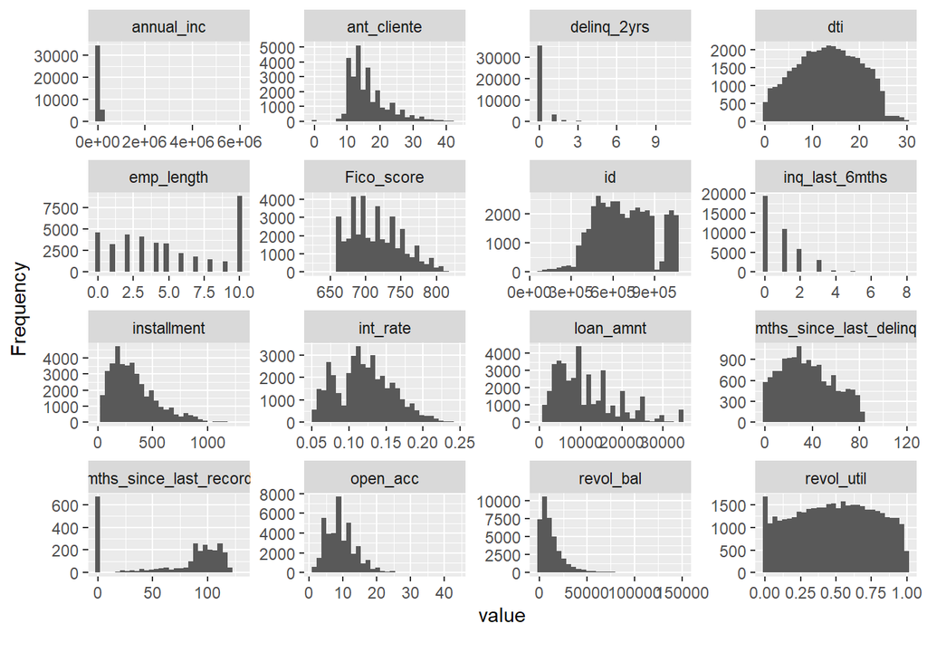

```r
plot_histogram(Loans[,numeric_vars])
```

Una vez tenemos todas las variables transformadas como queremos, podemos realizar un resumen de todas ellas:

```r
describe(Loans[,c(numeric_vars,categorical_vars)])
```

```
## Loans[, c(numeric_vars, categorical_vars)]
##
##  26  Variables      39786  Observations
## --------------------------------------------------------------------------------
## id
##        n  missing distinct     Info     Mean      Gmd      .05      .10
##    39786        0    39786        1   683394   240904   372506   427812
##      .25      .50      .75      .90      .95
##   516352   666230   837871  1007095  1039975
##
## lowest :   54734   55742   57245   57416   58915
## highest: 1075358 1076863 1077175 1077430 1077501
## --------------------------------------------------------------------------------
## loan_amnt
##        n  missing distinct     Info     Mean      Gmd      .05      .10
##    39786        0      885    0.999    11231     8109     2400     3200
##      .25      .50      .75      .90      .95
##     5500    10000    15000    22000    25000
##
## lowest :   500   700   725   750   800, highest: 34475 34525 34675 34800 35000
## --------------------------------------------------------------------------------
## int_rate
##        n  missing distinct     Info     Mean      Gmd      .05      .10
##    39786        0      371        1   0.1203  0.04241   0.0617   0.0714
##      .25      .50      .75      .90      .95
##   0.0925   0.1186   0.1459   0.1689   0.1862
##
## lowest : 0.0542 0.0579 0.0599 0.0600 0.0603, highest: 0.2359 0.2391 0.2411 0.2440 0.2459
## --------------------------------------------------------------------------------
## installment
##        n  missing distinct     Info     Mean      Gmd      .05      .10
##    39786        0    15405        1    324.7    226.1    71.23    99.50
##      .25      .50      .75      .90      .95
##   167.08   280.61   430.78   623.10   763.75
##
## lowest :   15.69   16.08   16.25   16.31   16.47
## highest: 1283.50 1288.10 1295.21 1302.69 1305.19
## --------------------------------------------------------------------------------
## emp_length
##        n  missing distinct     Info     Mean      Gmd      .05      .10
```

[output cut: 161 more lines]

```
## highest: www.music-housecalls.com--The Amadeus Home Music School will be using the loan to expand our Home Music Lesson business which currently has 250 instructors in 17 states.  The expansion will be to add Ontario and other states within the United States of America.  This will assist us in pa…
## --------------------------------------------------------------------------------
## purpose
##        n  missing distinct
##    39786        0       14
##
## lowest : car                credit_card        debt_consolidation educational        home_improvement
## highest: other              renewable_energy   small_business     vacation           wedding
## --------------------------------------------------------------------------------
## addr_state
##        n  missing distinct
##    39786        0       50
##
## lowest : AK AL AR AZ CA, highest: VT WA WI WV WY
## --------------------------------------------------------------------------------
```

Un mejor análisis puede ser llevado a cabo y además guardado en un documento Word:

```r
wrd<-GetNewWrd()
```

```
## ------------------------------------------------------------------------------
## Describe Loans[, c(numeric_vars, categorical_vars)] (tbl_df, tbl, data.frame):
##
## data frame:  39786 obs. of  26 variables
##      1016 complete cases (2.6%)
##
##   Nr  ColName                 Class      NAs            Levels
##   1   id                      numeric        .
##   2   loan_amnt               numeric        .
##   3   int_rate                numeric        .
##   4   installment             numeric        .
##   5   emp_length              numeric     1078 (2.7%)
##   6   annual_inc              numeric        .
##   7   loan_status             numeric        .
##   8   dti                     numeric        .
##   9   delinq_2yrs             numeric        .
##   10  Fico_score              numeric        .
##   11  inq_last_6mths          numeric        .
##   12  mths_since_last_delinq  numeric    25727 (64.7%)
##   13  mths_since_last_record  numeric    36995 (93.0%)
##   14  open_acc                numeric        .
##   15  revol_bal               numeric        .
##   16  revol_util              numeric       50 (0.1%)
##   17  ant_cliente             numeric    11612 (29.2%)
##   18  flag_cliente            numeric        .
##   19  term                    character      .
##   20  grade                   character      .
##   21  emp_title               character   2461 (6.2%)
##   22  home_ownership          character      .
##   23  verification_status     character      .
##   24  desc                    character  13176 (33.1%)
##   25  purpose                 character      .
##   26  addr_state              character      .
##
##
## ------------------------------------------------------------------------------
## 1 - id (numeric)
##
##         length           n         NAs      unique          0s          mean'
##         39'786      39'786           0         = n           0    683'393.95
##                     100.0%        0.0%                    0.0%
##
##            .05         .10         .25      median         .75           .90
##     372'506.25  427'812.00  516'351.75  666'229.50  837'871.00  1'007'094.50
##
##          range          sd       vcoef         mad         IQR          skew
##   1'022'767.00  210'677.00        0.31  237'147.80  321'519.25          0.08
##
##         meanCI
##     681'323.74
##     685'464.15
##
##            .95
##   1'039'974.75
##
##           kurt
##          -0.73
##
## lowest : 54'734.0, 55'742.0, 57'245.0, 57'416.0, 58'915.0
## highest: 1'075'358.0, 1'076'863.0, 1'077'175.0, 1'077'430.0, 1'077'501.0
##
## ' 95%-CI (classic)
```

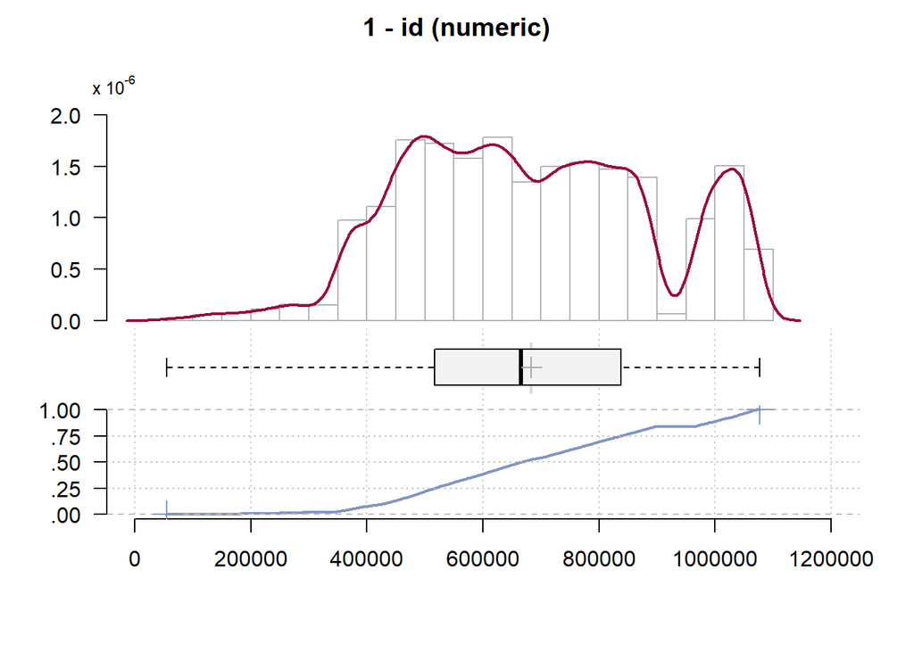

```
## ------------------------------------------------------------------------------
## 2 - loan_amnt (numeric)
##
##      length         n       NAs     unique         0s       mean     meanCI'
##      39'786    39'786         0        885          0  11'231.36  11'158.01
##                100.0%      0.0%                  0.0%             11'304.71
##
##         .05       .10       .25     median        .75        .90        .95
##    2'400.00  3'200.00  5'500.00  10'000.00  15'000.00  22'000.00  25'000.00
##
##       range        sd     vcoef        mad        IQR       skew       kurt
##   34'500.00  7'464.54      0.66   7'413.00   9'500.00       1.06       0.76
##
## lowest : 500.0 (5), 700.0, 725.0, 750.0, 800.0
## highest: 34'475.0 (5), 34'525.0, 34'675.0, 34'800.0 (2), 35'000.0 (685)
##
## heap(?): remarkable frequency (7.1%) for the mode(s) (= 10000)
##
## ' 95%-CI (classic)
```

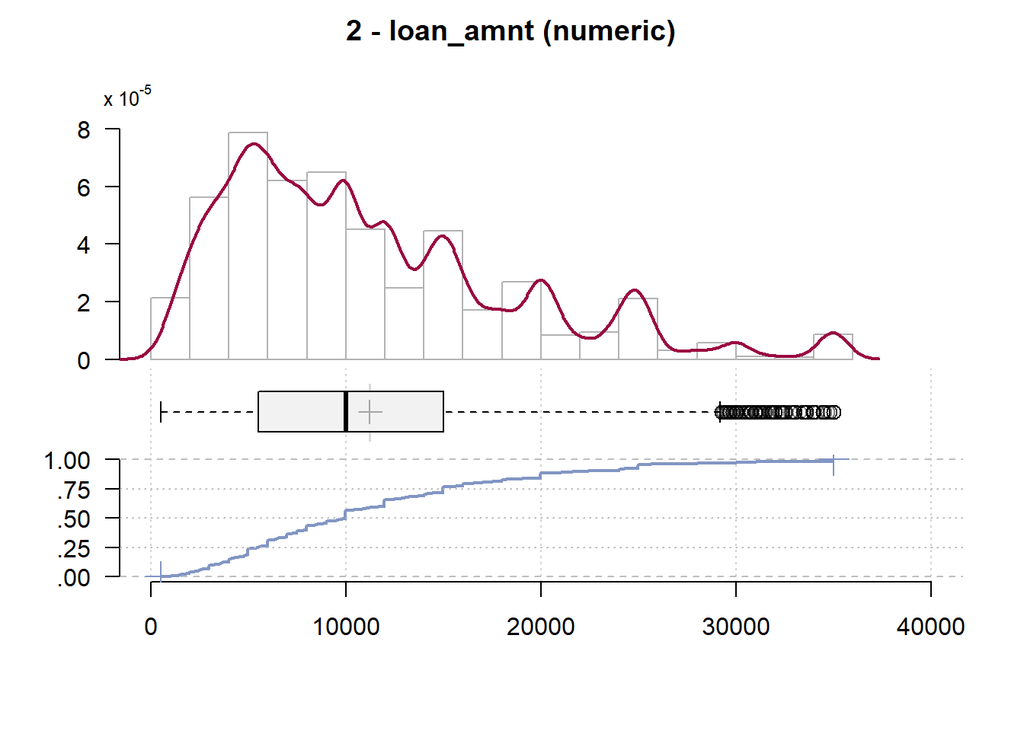

```
## ------------------------------------------------------------------------------
## 3 - int_rate (numeric)
##
##   length       n     NAs  unique      0s    mean   meanCI'
##   39'786  39'786       0     371       0  0.1203   0.1199
##           100.0%    0.0%            0.0%           0.1206
##
##      .05     .10     .25  median     .75     .90      .95
##   0.0617  0.0714  0.0925  0.1186  0.1459  0.1689   0.1862
##
##    range      sd   vcoef     mad     IQR    skew     kurt
##   0.1917  0.0373  0.3099  0.0397  0.0534  0.2929  -0.4493
##
## lowest : 0.0542 (573), 0.0579 (410), 0.0599 (347), 0.06 (18), 0.0603 (447)
## highest: 0.2359 (4), 0.2391 (11), 0.2411 (3), 0.244, 0.2459
##
## ' 95%-CI (classic)
```

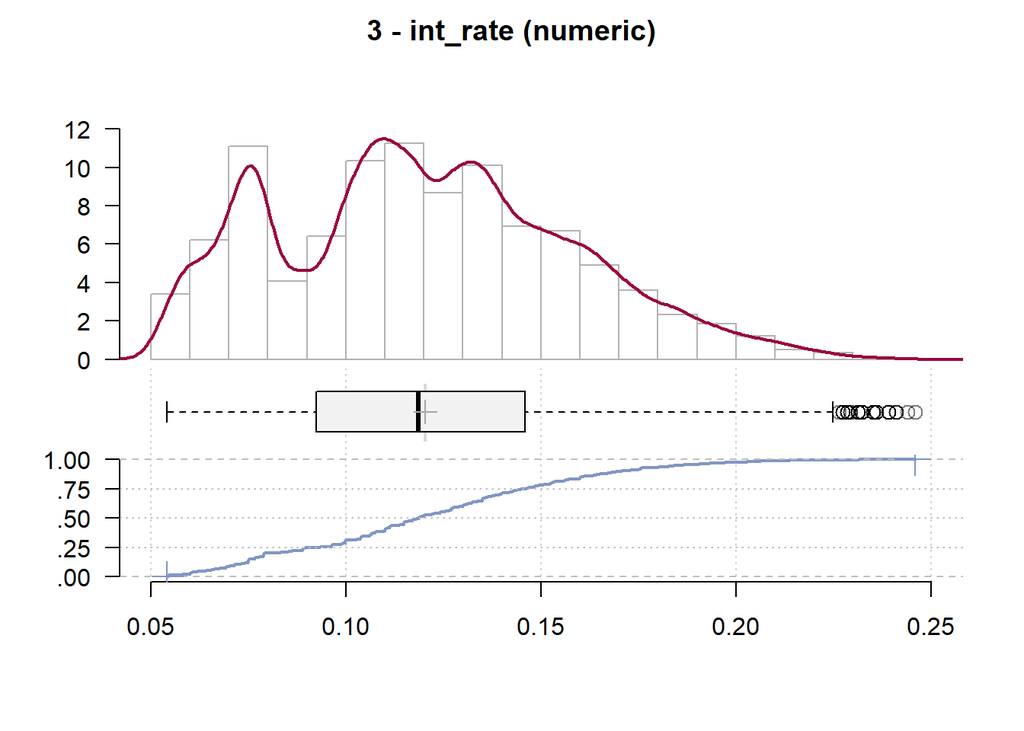

```
## ------------------------------------------------------------------------------
## 4 - installment (numeric)
##
##       length         n       NAs    unique        0s      mean    meanCI'
##       39'786    39'786         0    15'405         0  324.7336  322.6807
##                 100.0%      0.0%                0.0%            326.7866
##
##          .05       .10       .25    median       .75       .90       .95
##      71.2350   99.5000  167.0800  280.6100  430.7800  623.0950  763.7525
##
##        range        sd     vcoef       mad       IQR      skew      kurt
##   1'289.5000  208.9232    0.6434  182.9677  263.7000    1.1268    1.2409
##
## lowest : 15.69, 16.08, 16.25, 16.31, 16.47
## highest: 1'283.5000, 1'288.1000 (2), 1'295.2100, 1'302.6900, 1'305.1900
##
## ' 95%-CI (classic)
```

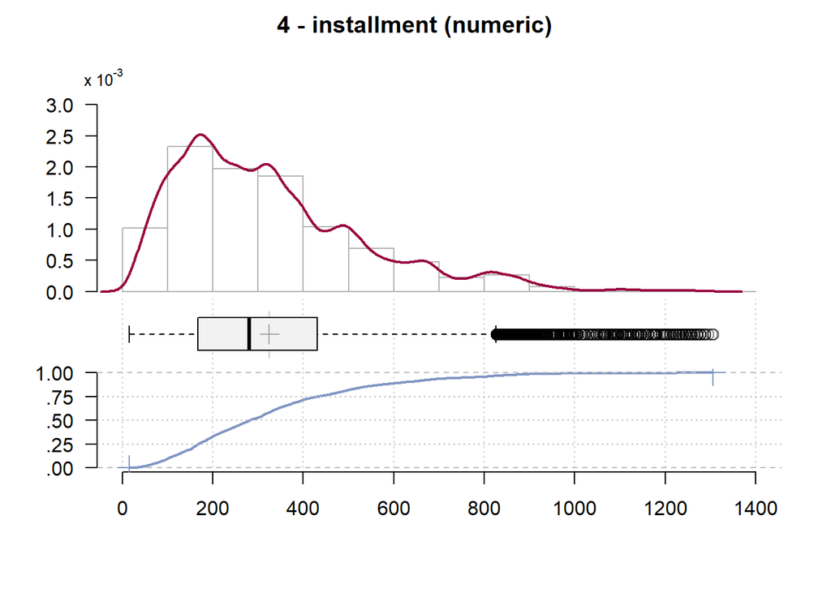

```
## ------------------------------------------------------------------------------
## 5 - emp_length (numeric)
##
##   length       n    NAs  unique     0s   mean  meanCI'
##   39'786  38'708  1'078      11  4'590   4.97    4.94
##            97.3%   2.7%          11.5%           5.01
##
##      .05     .10    .25  median    .75    .90     .95
##     0.00    0.00   2.00    4.00   9.00  10.00   10.00
##
##    range      sd  vcoef     mad    IQR   skew    kurt
##    10.00    3.56   0.72    4.45   7.00   0.20   -1.37
##
##
##     value   freq   perc  cumfreq  cumperc
## 1       0  4'590  11.9%    4'590    11.9%
## 2       1  3'247   8.4%    7'837    20.2%
## 3       2  4'394  11.4%   12'231    31.6%
## 4       3  4'098  10.6%   16'329    42.2%
## 5       4  3'444   8.9%   19'773    51.1%
## 6       5  3'286   8.5%   23'059    59.6%
## 7       6  2'231   5.8%   25'290    65.3%
## 8       7  1'775   4.6%   27'065    69.9%
## 9       8  1'485   3.8%   28'550    73.8%
## 10      9  1'259   3.3%   29'809    77.0%
## 11     10  8'899  23.0%   38'708   100.0%
##
## ' 95%-CI (classic)
```

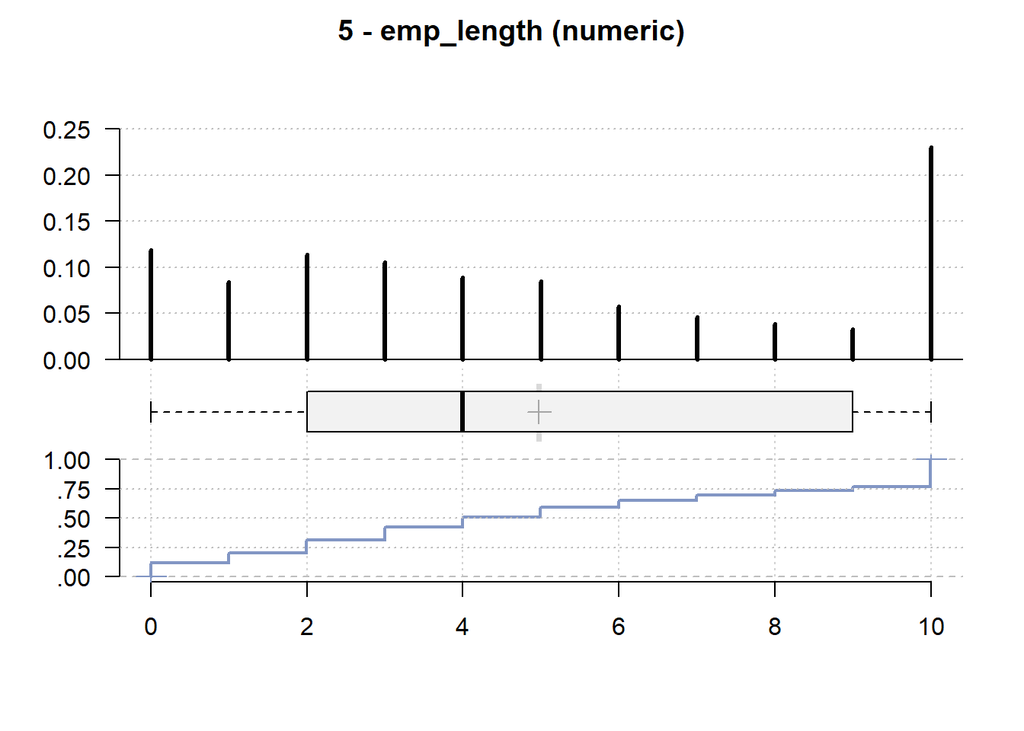

```
## ------------------------------------------------------------------------------
## 6 - annual_inc (numeric)
##
##         length          n        NAs     unique         0s        mean'
##         39'786     39'786          0      5'323          0   68'979.07
##                    100.0%       0.0%                  0.0%
##
##            .05        .10        .25     median        .75         .90
##      24'000.00  30'000.00  40'500.00  59'000.00  82'342.50  116'000.00
##
##          range         sd      vcoef        mad        IQR        skew
##   5'996'000.00  63'762.63       0.92  29'652.00  41'842.50       30.94
##
##       meanCI
##    68'352.51
##    69'605.63
##
##          .95
##   142'000.00
##
##         kurt
##     2'302.81
##
## lowest : 4'000.0, 4'080.0, 4'200.0 (2), 4'800.0 (4), 4'888.0
## highest: 1'782'000.0, 1'900'000.0, 2'039'784.0, 3'900'000.0, 6'000'000.0
##
## ' 95%-CI (classic)
```

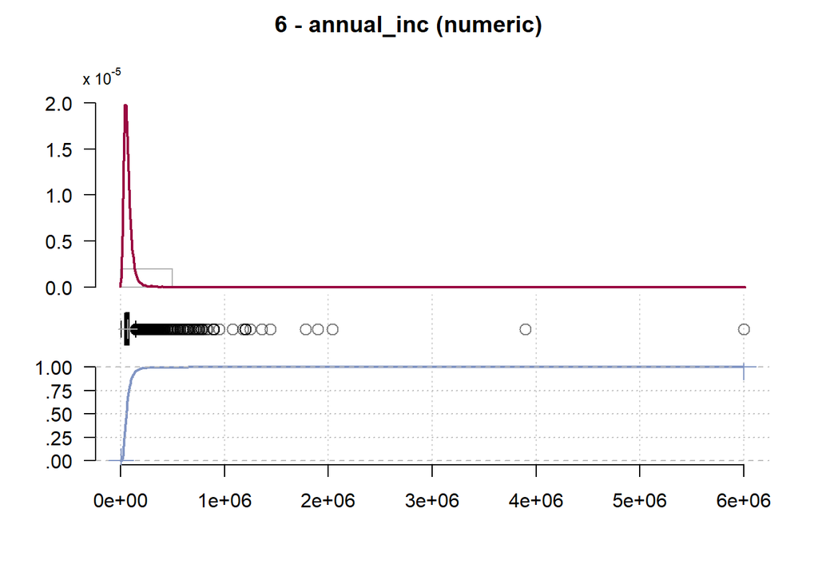

```
## ------------------------------------------------------------------------------
## 7 - loan_status (numeric)
##
##   length       n    NAs  unique      0s  mean  meanCI'
##   39'786  39'786      0       2  34'115  0.14    0.14
##           100.0%   0.0%           85.7%          0.15
##
##      .05     .10    .25  median     .75   .90     .95
##     0.00    0.00   0.00    0.00    0.00  1.00    1.00
##
##    range      sd  vcoef     mad     IQR  skew    kurt
##     1.00    0.35   2.45    0.00    0.00  2.04    2.18
##
##
##    value    freq   perc  cumfreq  cumperc
## 1      0  34'115  85.7%   34'115    85.7%
## 2      1   5'671  14.3%   39'786   100.0%
##
## ' 95%-CI (classic)
```

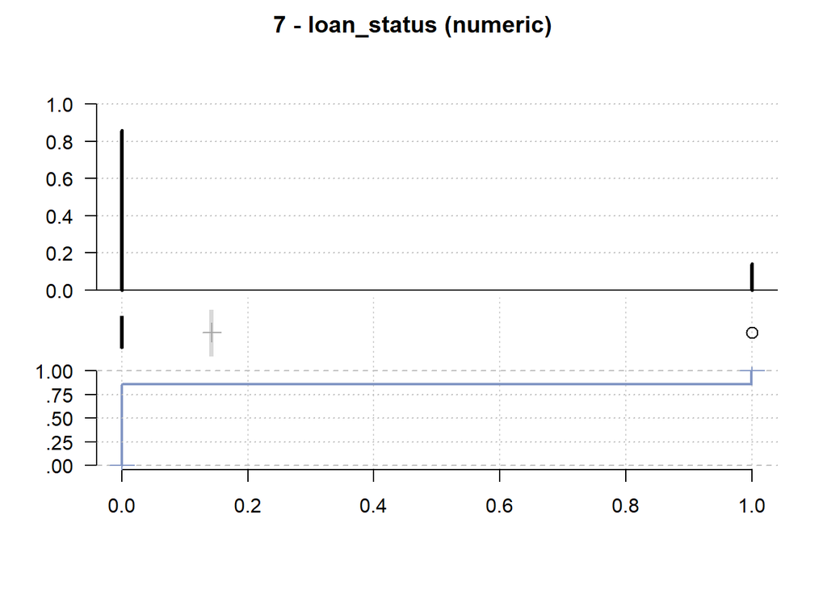

```
## ------------------------------------------------------------------------------
## 8 - dti (numeric)
##
##   length       n    NAs  unique      0s    mean  meanCI'
##   39'786  39'786      0   2'868     184  13.318  13.252
##           100.0%   0.0%            0.5%          13.383
##
##      .05     .10    .25  median     .75     .90     .95
##    2.130   4.090  8.180  13.410  18.600  22.335  23.840
##
##    range      sd  vcoef     mad     IQR    skew    kurt
##   29.990   6.678  0.501   7.724  10.420  -0.028  -0.851
##
## lowest : 0.0 (184), 0.01 (3), 0.02 (5), 0.03 (2), 0.04 (3)
## highest: 29.89, 29.92 (2), 29.93 (3), 29.95, 29.99
##
## ' 95%-CI (classic)
```

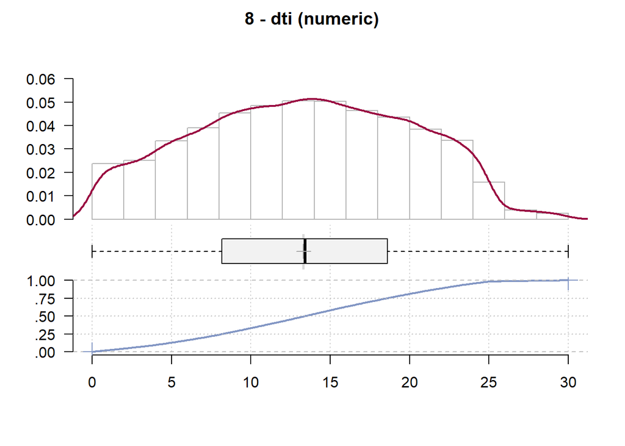

```
## ------------------------------------------------------------------------------
## 9 - delinq_2yrs (numeric)
##
##   length       n    NAs  unique      0s  mean  meanCI'
##   39'786  39'786      0      11  35'466  0.15    0.14
##           100.0%   0.0%           89.1%          0.15
##
##      .05     .10    .25  median     .75   .90     .95
##     0.00    0.00   0.00    0.00    0.00  1.00    1.00
##
##    range      sd  vcoef     mad     IQR  skew    kurt
##    11.00    0.49   3.36    0.00    0.00  5.02   39.36
##
##
##     value    freq   perc  cumfreq  cumperc
## 1       0  35'466  89.1%   35'466    89.1%
## 2       1   3'309   8.3%   38'775    97.5%
## 3       2     688   1.7%   39'463    99.2%
## 4       3     221   0.6%   39'684    99.7%
## 5       4      62   0.2%   39'746    99.9%
## 6       5      22   0.1%   39'768   100.0%
## 7       6      10   0.0%   39'778   100.0%
## 8       7       4   0.0%   39'782   100.0%
## 9       8       2   0.0%   39'784   100.0%
## 10      9       1   0.0%   39'785   100.0%
## 11     11       1   0.0%   39'786   100.0%
##
## ' 95%-CI (classic)
```

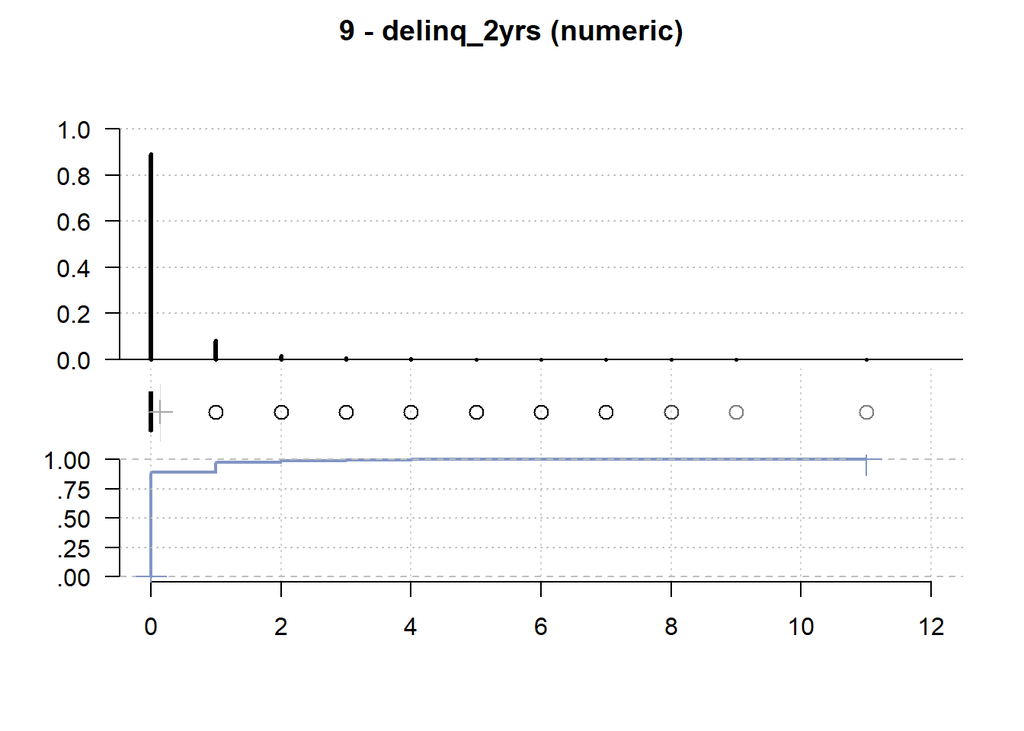

```
## ------------------------------------------------------------------------------
## 10 - Fico_score (numeric)
##
##   length       n     NAs  unique      0s    mean  meanCI'
##   39'786  39'786       0      36       0  715.00  714.65
##           100.0%    0.0%            0.0%          715.35
##
##      .05     .10     .25  median     .75     .90     .95
##   665.00  670.00  685.00  710.00  740.00  765.00  780.00
##
##    range      sd   vcoef     mad     IQR    skew    kurt
##   200.00   35.84    0.05   37.06   55.00    0.46   -0.56
##
## lowest : 625.0, 630.0, 660.0 (1'420), 665.0 (1'617), 670.0 (1'672)
## highest: 805.0 (190), 810.0 (125), 815.0 (28), 820.0 (19), 825.0 (3)
##
## heap(?): remarkable frequency (5.4%) for the mode(s) (= 700)
##
## ' 95%-CI (classic)
```

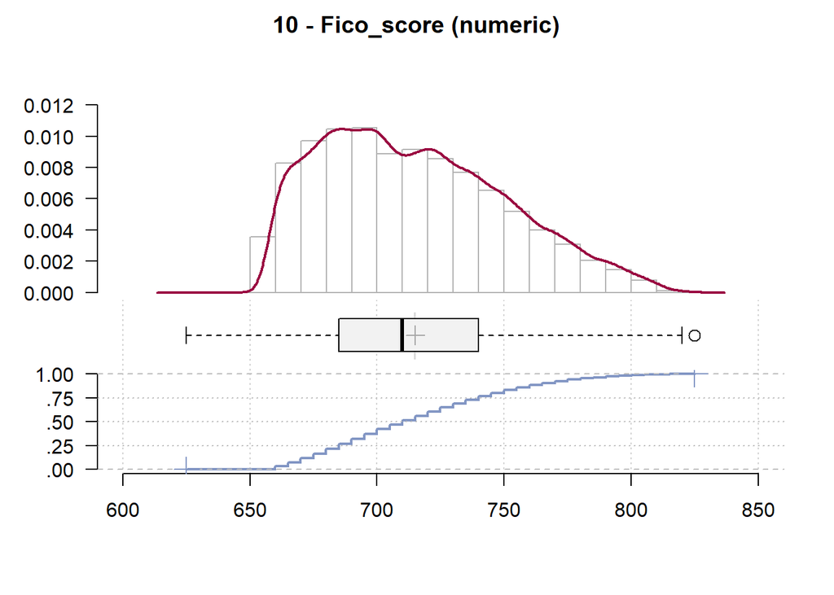

```
## ------------------------------------------------------------------------------
## 11 - inq_last_6mths (numeric)
##
##   length       n    NAs  unique      0s  mean  meanCI'
##   39'786  39'786      0       9  19'337  0.87    0.86
##           100.0%   0.0%           48.6%          0.88
##
##      .05     .10    .25  median     .75   .90     .95
##     0.00    0.00   0.00    1.00    1.00  2.00    3.00
##
##    range      sd  vcoef     mad     IQR  skew    kurt
##     8.00    1.07   1.23    1.48    1.00  1.39    2.56
##
##
##    value    freq   perc  cumfreq  cumperc
## 1      0  19'337  48.6%   19'337    48.6%
## 2      1  10'986  27.6%   30'323    76.2%
## 3      2   5'824  14.6%   36'147    90.9%
## 4      3   3'053   7.7%   39'200    98.5%
## 5      4     326   0.8%   39'526    99.3%
## 6      5     146   0.4%   39'672    99.7%
## 7      6      64   0.2%   39'736    99.9%
## 8      7      35   0.1%   39'771   100.0%
## 9      8      15   0.0%   39'786   100.0%
##
## ' 95%-CI (classic)
```

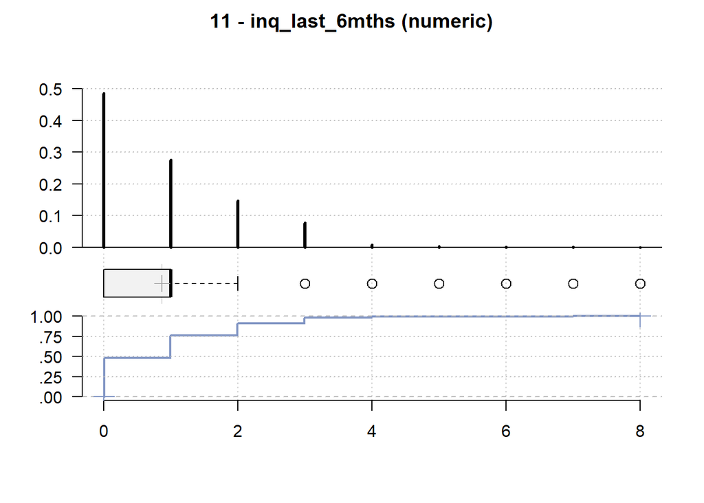

```
## ------------------------------------------------------------------------------
## 12 - mths_since_last_delinq (numeric)
##
##   length       n     NAs  unique     0s   mean  meanCI'
##   39'786  14'059  25'727      95    443  35.90   35.54
##            35.3%   64.7%           1.1%          36.27
##
##      .05     .10     .25  median    .75    .90     .95
##     3.00    8.00   18.00   34.00  52.00  69.00   75.00
##
##    range      sd   vcoef     mad    IQR   skew    kurt
##   120.00   22.02    0.61   25.20  34.00   0.31   -0.84
##
## lowest : 0.0 (443), 1.0 (30), 2.0 (101), 3.0 (145), 4.0 (153)
## highest: 103.0 (2), 106.0, 107.0, 115.0, 120.0
##
## ' 95%-CI (classic)
```

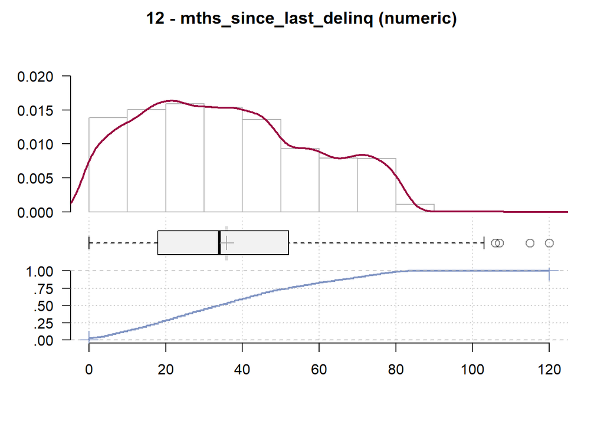

```
## ------------------------------------------------------------------------------
## 13 - mths_since_last_record (numeric)
##
##   length      n     NAs  unique      0s    mean  meanCI'
##   39'786  2'791  36'995     111     670   69.75   68.12
##            7.0%   93.0%            1.7%           71.37
##
##      .05    .10     .25  median     .75     .90     .95
##     0.00   0.00   22.50   90.00  104.00  113.00  115.00
##
##    range     sd   vcoef     mad     IQR    skew    kurt
##   129.00  43.81    0.63   29.65   81.50   -0.72   -1.15
##
## lowest : 0.0 (670), 5.0, 6.0, 7.0, 11.0 (2)
## highest: 117.0 (47), 118.0 (36), 119.0 (10), 120.0, 129.0
##
## heap(?): remarkable frequency (24.0%) for the mode(s) (= 0)
##
## ' 95%-CI (classic)
```

[14 more figures not shown]

```r
Desc(Loans[,c(numeric_vars,categorical_vars)],plotit = T,wrd=wrd)
```

Vamos a ver algunos gráficos de evolución de los préstamos que tenemos disponibles en la base de datos. Por ejemplo, la evolución de la tasa de defaults a lo largo del tiempo:

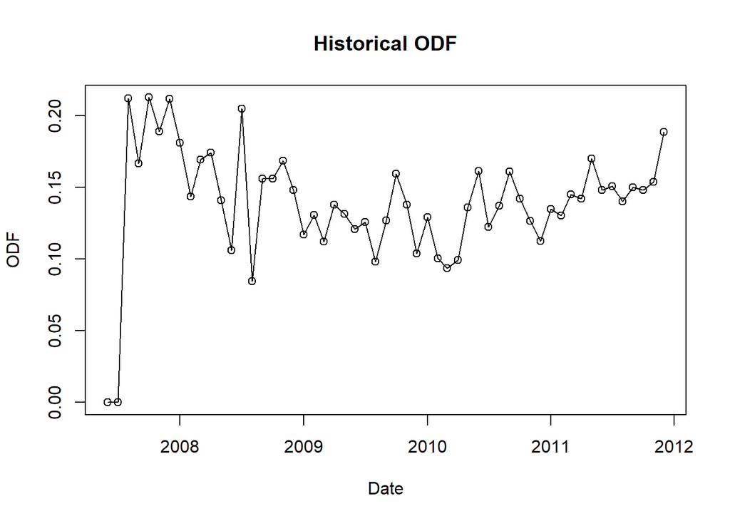

```r
Hist_defaults<-sqldf("SELECT issue_d,

      count(loan_status) as N,

      sum(loan_status) as Defaults,

      avg(loan_status) as ODF

      from Loans group by issue_d")


plot(Hist_defaults$issue_d, Hist_defaults$ODF, main="Historical ODF",xlab="Date",ylab="ODF")
lines(Hist_defaults$issue_d, Hist_defaults$ODF)
```

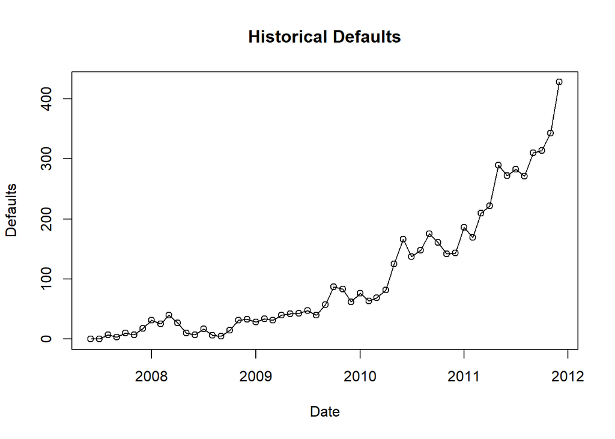

```r
plot(Hist_defaults$issue_d, Hist_defaults$Defaults, main="Historical Defaults",xlab="Date",ylab="Defaults")
lines(Hist_defaults$issue_d, Hist_defaults$Defaults)
```

Tenemos dos cosas aqui: - Por un lado, la tasa de default ha permanecido más o menos constante, ¿verdad? - Pero por otro lado vemos que los defaults han aumentado mucho. ¿Qué ha podido suceder?

Vamos entonces a ver también la evolución en el número de préstamos:

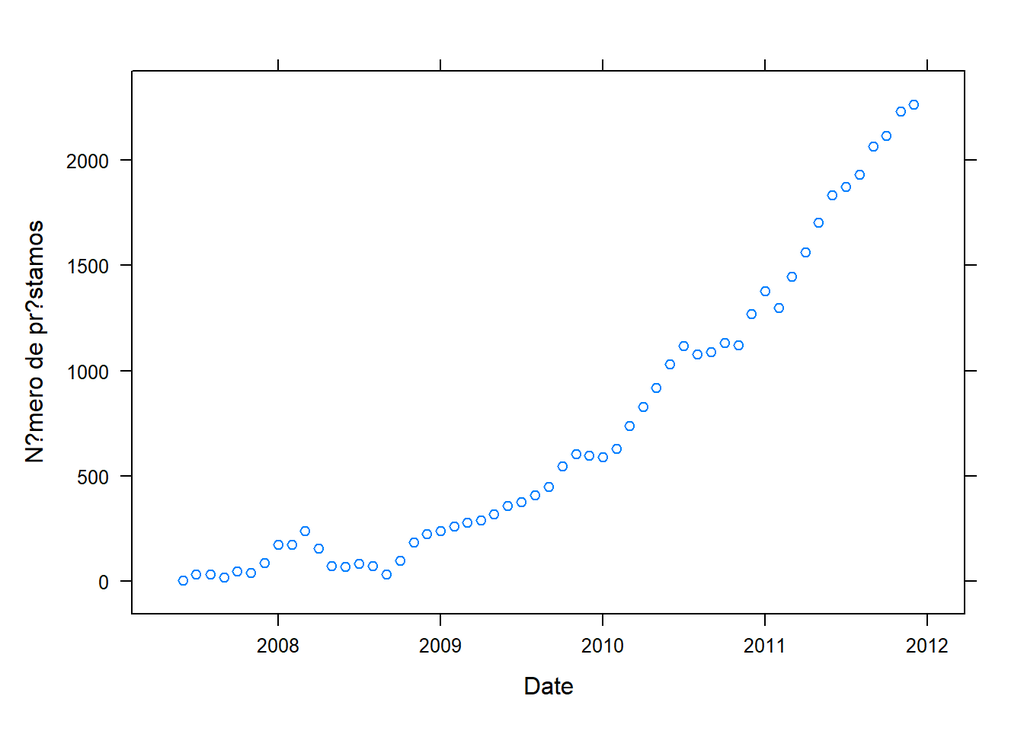

```r
evolucion_prestamos<-sqldf("SELECT issue_d,

      count(loan_amnt) as Num_prestamos

      from Loans group by issue_d")

library(lattice)
xyplot(Num_prestamos  ~ issue_d, data=evolucion_prestamos,ylab="N?mero de pr?stamos", xlab="Date",auto.key = TRUE)
```

También la evolución del importe medio concedido:

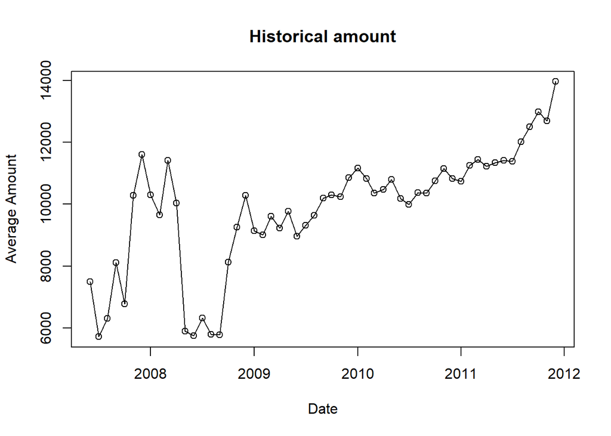

```r
evolucion_importe<-sqldf("SELECT issue_d,

      avg(loan_amnt) as Average_amount

      from Loans group by issue_d")


plot(evolucion_importe$issue_d, evolucion_importe$Average_amount, main="Historical amount",xlab="Date",ylab="Average Amount")
lines(evolucion_importe$issue_d, evolucion_importe$Average_amount)
```

Ahora vamos a ver si tenemos las variables lo suficientemente informadas y si nos interesa mantener todas las variables por este motivo. Primero calculamos el número de registros missing por variable:

```r
data=Loans
ncol=rep(nrow(data) ,each=ncol(data))
nmsg=as.integer(as.character(as.vector(apply(data, 2, function(x) length(which(is.na(x)))))))
missingdata=as.data.frame(cbind(colnames=names(data),ncol,nmsg))
# missingdata$nmsg=as.numeric(levels(missingdata$nmsg))[missingdata$nmsg]
missingdata$nmsg<-as.numeric(missingdata$nmsg)
missingdata=cbind(missingdata,percmissing=(missingdata$nmsg/ncol*100))

print(nmsg)
```

```
##  [1]     0     0     0     0     0     0  2461  1078     0     0     0     0
## [13]     0 13176     0     0     0     0 11612     0     0 25727 36995     0
## [25]     0    50 11612     0
```

```r
print(missingdata)
```

```
##                  colnames  ncol  nmsg percmissing
## 1                      id 39786     0   0.0000000
## 2               loan_amnt 39786     0   0.0000000
## 3                    term 39786     0   0.0000000
## 4                int_rate 39786     0   0.0000000
## 5             installment 39786     0   0.0000000
## 6                   grade 39786     0   0.0000000
## 7               emp_title 39786  2461   6.1855929
## 8              emp_length 39786  1078   2.7094958
## 9          home_ownership 39786     0   0.0000000
## 10             annual_inc 39786     0   0.0000000
## 11    verification_status 39786     0   0.0000000
## 12                issue_d 39786     0   0.0000000
## 13            loan_status 39786     0   0.0000000
## 14                   desc 39786 13176  33.1171769
## 15                purpose 39786     0   0.0000000
## 16             addr_state 39786     0   0.0000000
## 17                    dti 39786     0   0.0000000
## 18            delinq_2yrs 39786     0   0.0000000
## 19       earliest_cr_line 39786 11612  29.1861459
## 20             Fico_score 39786     0   0.0000000
## 21         inq_last_6mths 39786     0   0.0000000
## 22 mths_since_last_delinq 39786 25727  64.6634495
## 23 mths_since_last_record 39786 36995  92.9849696
## 24               open_acc 39786     0   0.0000000
## 25              revol_bal 39786     0   0.0000000
## 26             revol_util 39786    50   0.1256723
## 27            ant_cliente 39786 11612  29.1861459
## 28           flag_cliente 39786     0   0.0000000
```

Vamos a ver las variables que tengan más de un 10% de valores missing:

```r
print(missingdata[missingdata$percmissing>10,])
```

```
##                  colnames  ncol  nmsg percmissing
## 14                   desc 39786 13176    33.11718
## 19       earliest_cr_line 39786 11612    29.18615
## 22 mths_since_last_delinq 39786 25727    64.66345
## 23 mths_since_last_record 39786 36995    92.98497
## 27            ant_cliente 39786 11612    29.18615
```

```r
Loans$earliest_cr_line<-NULL
```

Anteriormente vimos que la tasa de malos alcanzaba el 14.25%. ¿Cuál es la tasa de malos en la muestra cuando la variable “ant_cliente” viene a missing?:

```r
sqldf("SELECT
      avg(loan_status) as FDO

      from Loans where ant_cliente is null")
```

```
##        FDO
## 1 0.146917
```

Parece que es ligeramente superior y que los clientes con el valor a missing se comportan ligeramente peor que la media. Podríamos asignar el valor medio de la variable a los valores faltantes pero estaríamos perdiendo información. También podemos suponer que son clientes nuevos y sin antigüedad, pudiendo asignar un cero como valor. Eliminar los registros no es muy buena opción, pues estaríamos suprimiendo el 29% de la base de datos.

Otra opción es borrar la variable. En este caso vamos a mantener la variable sin realizar nada sobre ella pues luego agruparemos la variable y crearemos un grupo con los valores missing.

Analicemos ahora la tasa de defaults en los casos faltantes de la variable “mths_since_last_delinq” en la que recordemos que había un 65% de registros missing:

```r
sqldf("SELECT
      avg(loan_status) as FDO

      from Loans where mths_since_last_delinq is null")
```

```
##        FDO
## 1 0.136588
```

En estos casos, los préstamos cuya variable tiene valores missing se comportaran mejor que la media de la cartera de nuestra muestra. Parece lógico pensar que valores missing podrían recoger aquellos préstamos cuyos solicitantes nunca han tenido atrasos en los pagos. Por lo tanto este tipo de “missing” puede ser realmente un dato a tener en cuenta

Por último, vemos la tasa de default en la variable “mths_since_last_record”:

```r
sqldf("SELECT
      avg(loan_status) as FDO

      from Loans where mths_since_last_record is null")
```

```
##         FDO
## 1 0.1375591
```

El racional viene a ser el mismo que la anterior variable. Otra manera de ver los valores missing:

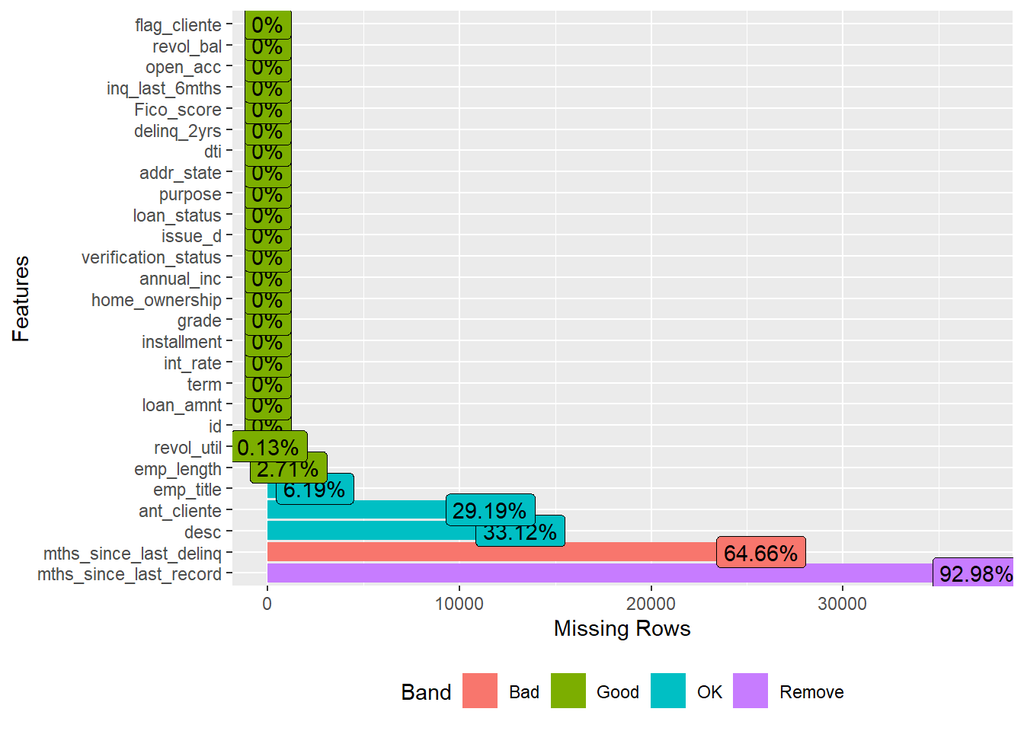

```r
plot_missing(Loans)
```

Nos puede interesar suprimir aquellos registros que tengan más de un porcentaje de valores missing en todas las variables. Se podrían tratar de solicitudes de préstamos erróneas y que pueden afectar a nuestro modelo:

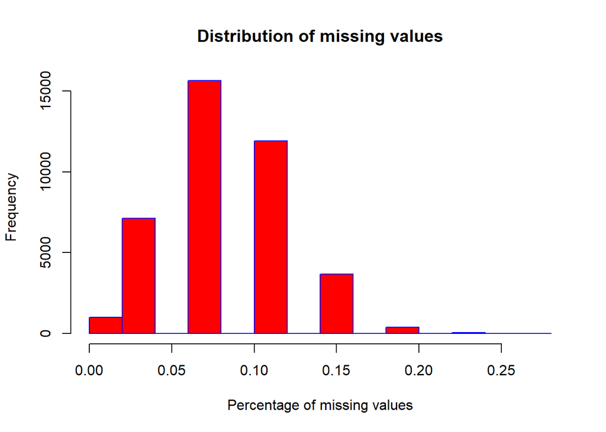

```r
Loans$missingvalues<-rowSums(is.na(Loans[,2:27]))/26
hist(Loans$missingvalues,main="Distribution of missing values",xlab="Percentage of missing values",border="blue", col="red",breaks=10)
```

```r
summary(Loans$missingvalues)
```

```
##    Min. 1st Qu.  Median    Mean 3rd Qu.    Max.
## 0.00000 0.07692 0.07692 0.08807 0.11538 0.26923
```

Suelen eliminarse aquellos registros con un % de valores missing superior al 30%. En este caso no eliminaremos observaciones.

```r
Loans$missingvalues<-NULL
```

Visualmente se pueden ver los valores faltantes con el siguiente paquete:

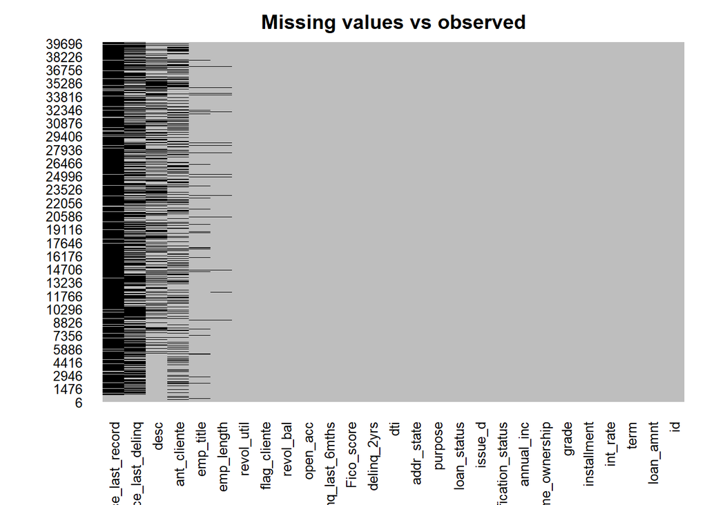

```r
missmap(Loans, main = "Missing values vs observed",col=c("black", "grey"),,legend = FALSE)
```

```r
rm(list=setdiff(ls(), c("Loans","numeric_vars","categorical_vars")))

save.image("Backup2.RData")
```

Para construir el modelo vamos a partir nuestros datos en muestra de desarrollo y validación. El 70% de los datos se usarán para desarrollar el modelo y el 30% restante para validar el modelo sobre una muestra diferente a la de construcción. Se pretende también que la selección aleatoria de la muestra mantenga la misma tasa de default en ambas muestras:

```r
set.seed(1234)
index = sample.split(Loans$loan_status, SplitRatio = .70)
train<-subset(Loans, index == TRUE)
test<-subset(Loans, index == FALSE)
```

Vamos a comprobar el tamaño de ambas muestras y la tasa de default en cada una de ellas:

```r
print("La muestra de entrenamiento tiene un total de:")
```

```
## [1] "La muestra de entrenamiento tiene un total de:"
```

```r
nrow(train)
```

```
## [1] 27850
```

```r
print("y tiene una tasa de defaults de:")
```

```
## [1] "y tiene una tasa de defaults de:"
```

```r
mean(train$loan_status)
```

```
## [1] 0.1425494
```

```r
print("La muestra de validación tiene un total de:")
```

```
## [1] "La muestra de validación tiene un total de:"
```

```r
nrow(test)
```

```
## [1] 11936
```

```r
print("y tiene una tasa de defaults de:")
```

```
## [1] "y tiene una tasa de defaults de:"
```

```r
mean(test$loan_status)
```

```
## [1] 0.1425101
```

```r
print("La muestra de entrenamiento tiene un tamaño del")
```

```
## [1] "La muestra de entrenamiento tiene un tamaño del"
```

```r
nrow(train)/nrow(Loans)
```

```
## [1] 0.699995
```

Hasta ahora hemos descrito los datos pero vamos a hacer un modelo que relacione esas variables con el default. ¿Como es esa relación de cada variable con la variable de desempeño de los préstamos?. Vamos a hacer un análisis gráfico inicial de cada variable:

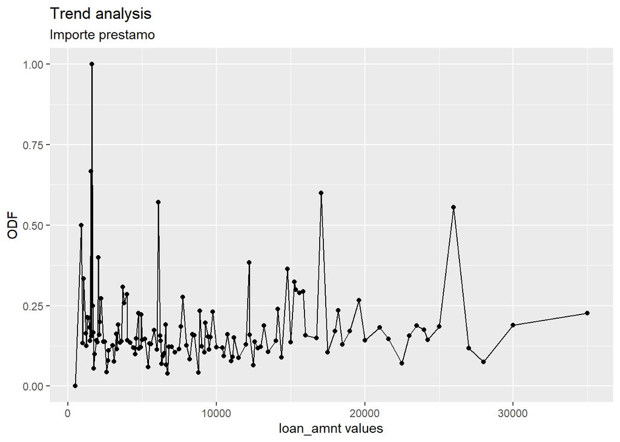

```r
trends<-function(variable,label){


temp <- train[,c(variable,"loan_status")]

if (class(temp[,1])=="numeric") {

temp$quartile <- as.numeric(cut2(temp[,1], g=6))   #as.numeric to number the factors
temp$quartileBounds <- cut2(temp[,1], g=6)
temp$Interval <- paste(temp$quartile," - ",temp$quartileBounds,sep='')

results<-sqldf("SELECT  Interval,

      count(loan_status) as N,

      sum(loan_status) as Defaults,

      avg(loan_status) as ODF

      from temp group by Interval")


library(ggplot2)
# Basic line plot with points
ggplot(data=results, aes(x=Interval, y=ODF, group=1)) +
  geom_line()+
  geom_point() +   labs(title="Trend analysis",
    subtitle=paste(label,sep=''),
         x=paste(variable, "values",sep=' '),
         fill="loan_status")

} else {

temp <- train[,c(variable,"loan_status")]

colnames(temp)[1]<-"var"

results<-sqldf("SELECT  var,

      count(loan_status) as N,

      sum(loan_status) as Defaults,

      avg(loan_status) as ODF

      from temp group by  var")

results<-sqldf("SELECT  *

      from results group by  ODF")

library(ggplot2)
# Basic line plot with points
ggplot(data=results, aes(x=var, y=ODF, group=1)) +
  geom_line()+
  geom_point() +   labs(title="Trend analysis",
    subtitle=paste(label,sep=''),
         x=paste(variable, "values",sep=' '),
         fill="loan_status")


}

}

trends("loan_amnt","Importe prestamo")
```

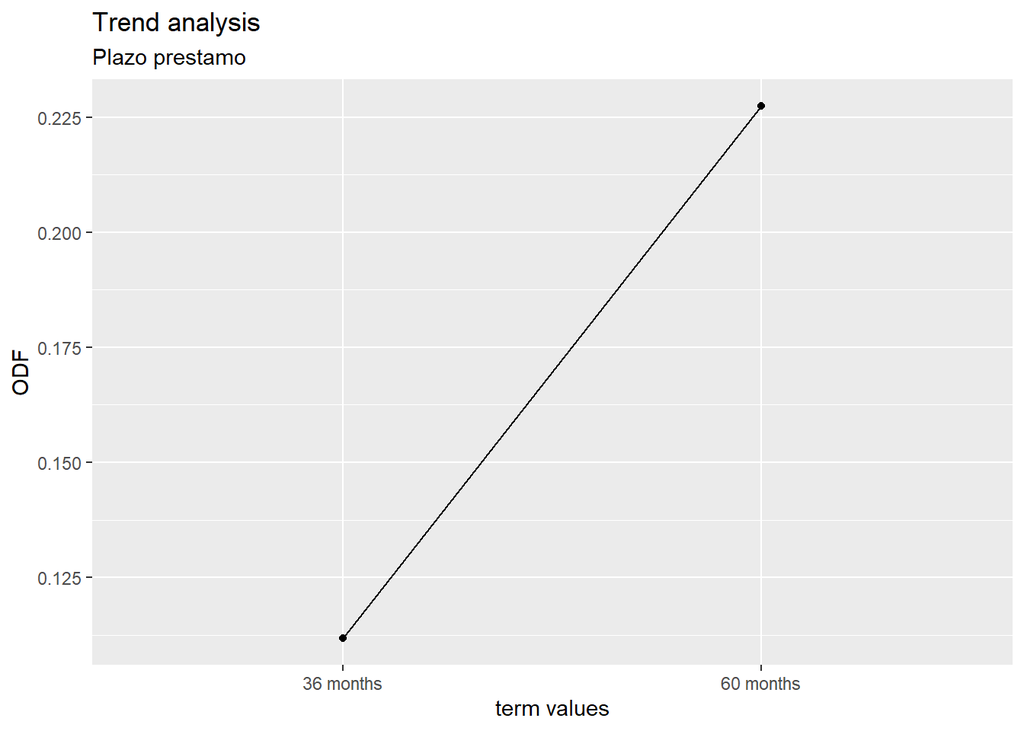

```r
trends("term","Plazo prestamo")
```

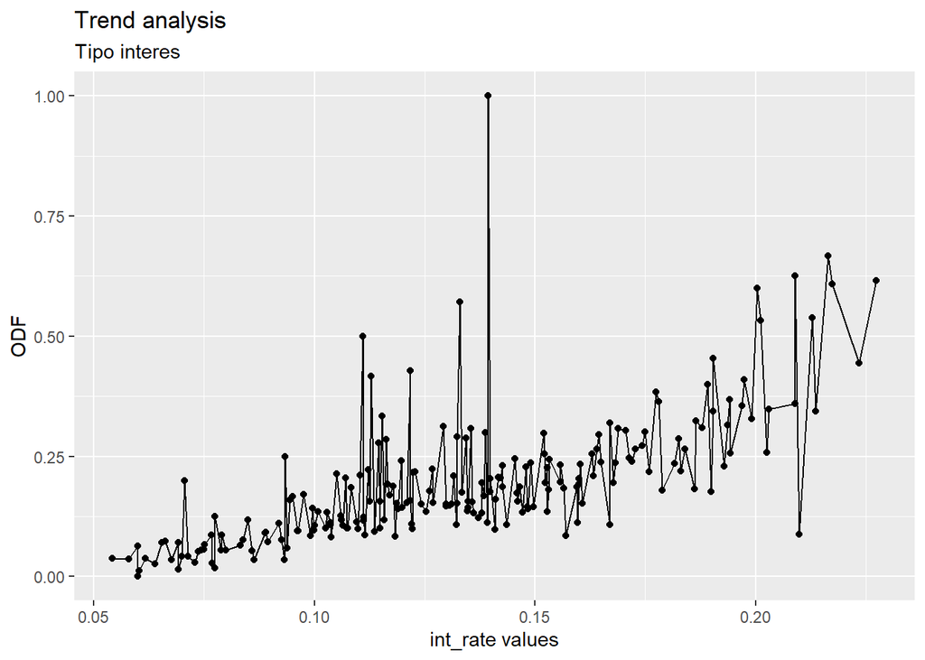

```r
trends("int_rate","Tipo interes")
```

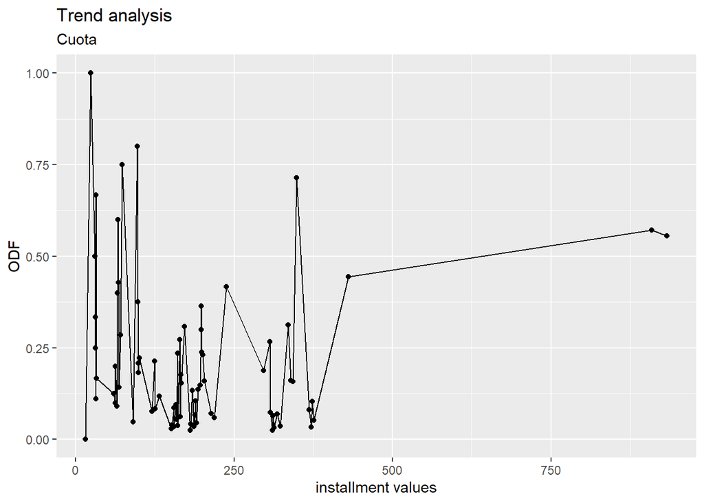

```r
trends("installment","Cuota")
```

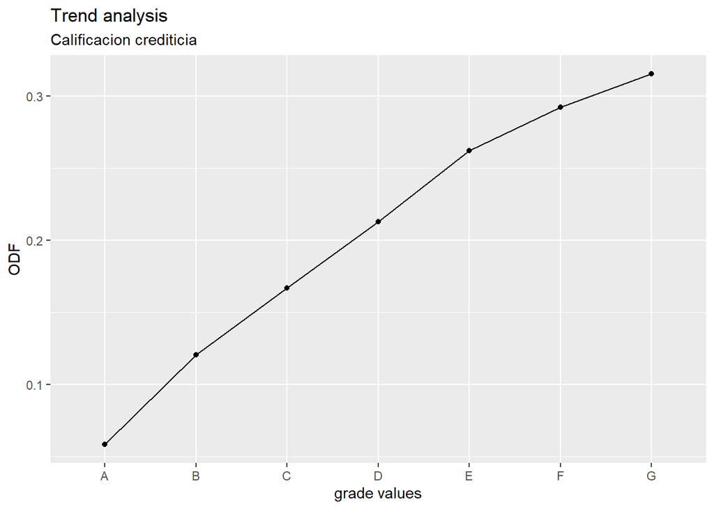

```r
trends("grade","Calificacion crediticia")
```

[figure not shown]

```r
trends("emp_title","Profesion")
```

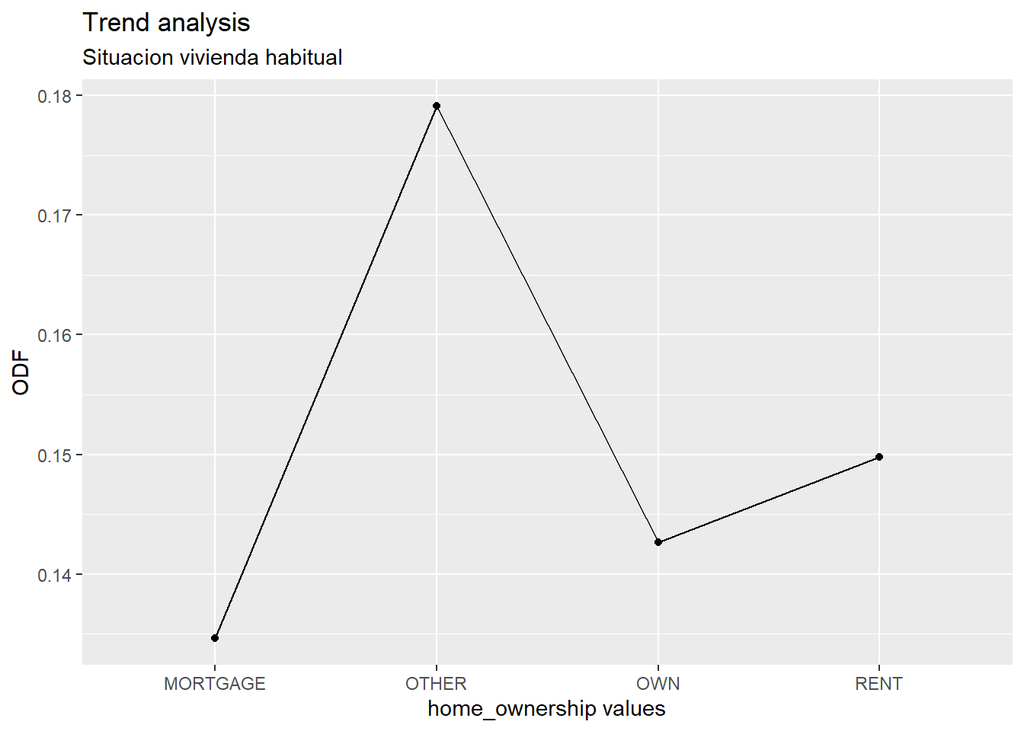

```r
trends("home_ownership","Situacion vivienda habitual")
```

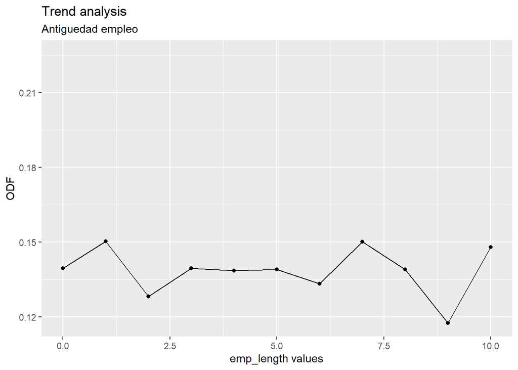

```r
trends("emp_length","Antiguedad empleo")
```

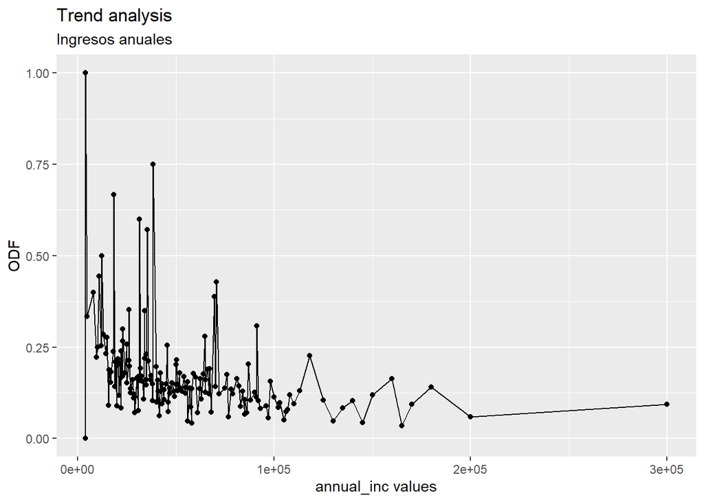

```r
trends("annual_inc","Ingresos anuales")
```

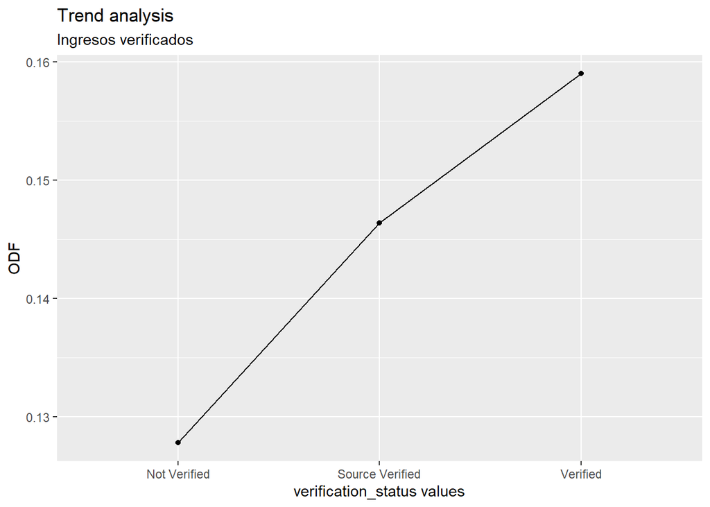

```r
trends("verification_status","Ingresos verificados")
```